Fuente código: Coursera, código mejorado y usado por Fernando Gutiérrez - Curso de Mineria de datos UCC-2023-2.

# Analizando los datos

[output not shown]

```python
pip install missingno
```

```python
#Importar librerias

import pandas as pd # módulo para tratamiento de datos
import numpy as np # módulo para tratamiento de matrices
import missingno as msno # librería para tratamiento de datos perdidos
import matplotlib.pyplot as plt # módulo graficador
import seaborn as sns
%matplotlib inline

import warnings
warnings.filterwarnings('ignore')
```

```python
# Informacion de los Datos fraude financiero dataset
data = pd.read_csv("data_FraudDetection_JAR2020.csv")
data.sample(10)
```

|  | fyear | gvkey | p_aaer | misstate | act | ap | at | ceq | che | cogs | ... | soft_assets | ch_cs | ch_cm | ch_roa | issue | bm | dpi | reoa | EBIT | ch_fcf |
| --- | --- | --- | --- | --- | --- | --- | --- | --- | --- | --- | --- | --- | --- | --- | --- | --- | --- | --- | --- | --- | --- |
| 27193 | 1995 | 9489 | NaN | 0 | 7.580 | 0.357 | 13.682 | -2.394 | 2.464 | 0.319 | ... | 0.750402 | -0.856824 | -1.984264 | 0.032042 | 1 | -7.034304 | 2.743048 | 0.346952 | -0.085075 | 0.131585 |
| 3843 | 1990 | 14927 | NaN | 0 | 6.503 | 5.661 | 106.581 | 84.738 | 0.062 | 4.339 | ... | 0.060433 | 0.243370 | 0.218997 | 0.008314 | 1 | 0.769761 | 0.918759 | 0.137510 | 0.082491 | -0.139674 |
| 70466 | 2001 | 108550 | NaN | 0 | 1.185 | 2.555 | 18.373 | 11.098 | 1.165 | 0.055 | ... | 0.040113 | -0.324759 | -15.494570 | -0.146006 | 1 | 0.273079 | 0.151757 | -0.181952 | -0.171121 | -0.571374 |
| 76011 | 2002 | 65494 | NaN | 0 | 81.172 | 13.709 | 126.096 | 52.359 | 11.145 | 125.213 | ... | 0.612081 | -0.236779 | 0.036349 | -0.146969 | 1 | 0.326044 | 1.052087 | 0.350844 | -0.097695 | -0.174122 |
| 112865 | 2008 | 210216 | NaN | 0 | 5271.531 | 668.384 | 36260.060 | 11490.655 | 878.748 | 13722.426 | ... | 0.334669 | 0.234601 | 0.104708 | 0.009583 | 1 | 0.226961 | 0.967408 | 0.170961 | 0.165581 | 0.015346 |
| 122498 | 2010 | 164284 | NaN | 0 | 0.158 | 0.211 | 1.415 | 0.058 | 0.046 | 0.000 | ... | 0.949117 | NaN | NaN | NaN | 1 | 0.013314 | 0.860465 | -3.435336 | -0.616254 | 0.336006 |
| 42900 | 1997 | 29401 | NaN | 0 | 5.852 | 1.324 | 11.702 | 9.894 | 3.395 | 9.890 | ... | 0.212870 | 0.153304 | -9.891709 | -1.499305 | 1 | 0.281674 | 0.152289 | -1.795249 | -1.501709 | -1.701100 |
| 94630 | 2005 | 141781 | NaN | 0 | 7.658 | 0.930 | 10.194 | 6.887 | 4.681 | 7.790 | ... | 0.418089 | NaN | NaN | NaN | 1 | 0.158488 | 1.074586 | -1.431921 | -0.298215 | 0.246240 |
| 42937 | 1997 | 29612 | NaN | 0 | 43.922 | 5.284 | 139.194 | 45.794 | 1.845 | 168.465 | ... | 0.384837 | 0.108233 | -0.005538 | 0.146500 | 0 | 0.522378 | 0.856823 | -0.070283 | 0.090758 | -0.004311 |
| 15354 | 1993 | 5988 | NaN | 0 | 206.992 | 19.403 | 364.393 | 145.794 | 92.598 | 155.091 | ... | 0.589781 | -0.011415 | -0.000288 | 0.146683 | 1 | 0.344540 | 0.911495 | 0.336370 | 0.178642 | 0.027081 |

10 rows × 46 columns

# Tamaño del dataset

```python
data.shape
```

```
(146045, 46)
```

# Información datos

```python
data.info()
```

```
<class 'pandas.core.frame.DataFrame'>
RangeIndex: 146045 entries, 0 to 146044
Data columns (total 46 columns):
 #   Column       Non-Null Count   Dtype
---  ------       --------------   -----
 0   fyear        146045 non-null  int64
 1   gvkey        146045 non-null  int64
 2   p_aaer       964 non-null     float64
 3   misstate     146045 non-null  int64
 4   act          146045 non-null  float64
 5   ap           146045 non-null  float64
 6   at           146045 non-null  float64
 7   ceq          146045 non-null  float64
 8   che          146045 non-null  float64
 9   cogs         146045 non-null  float64
```

[output cut: 38 more lines]

# Informe estadístico

```python
# Empezamos realizando un análisis descriptivo de las variables para entender sus dimensiones
data.describe()
```

|  | fyear | gvkey | p_aaer | misstate | act | ap | at | ceq | che | cogs | ... | soft_assets | ch_cs | ch_cm | ch_roa | issue | bm | dpi | reoa | EBIT | ch_fcf |
| --- | --- | --- | --- | --- | --- | --- | --- | --- | --- | --- | --- | --- | --- | --- | --- | --- | --- | --- | --- | --- | --- |
| count | 146045.000000 | 146045.000000 | 964.000000 | 146045.000000 | 146045.000000 | 146045.000000 | 146045.000000 | 146045.000000 | 146045.000000 | 146045.000000 | ... | 145453.000000 | 130127.000000 | 128938.000000 | 133367.000000 | 146045.000000 | 146027.000000 | 136817.000000 | 145454.000000 | 145454.000000 | 140638.000000 |
| mean | 2002.011702 | 54243.435516 | 2503.840249 | 0.006601 | 737.847759 | 181.993488 | 2374.041576 | 887.126243 | 218.657186 | 1302.280756 | ... | 0.499790 | 0.185169 | -0.090980 | -0.010208 | 0.863487 | 0.466137 | 1.042207 | -3.191197 | -0.238754 | -0.008842 |
| std | 6.959894 | 59937.455765 | 912.093250 | 0.080976 | 3744.542368 | 1047.546104 | 11957.736980 | 5056.948150 | 1330.490185 | 7870.665783 | ... | 0.274129 | 1.383354 | 2.844807 | 0.379574 | 0.343333 | 1.314661 | 0.495286 | 12.932219 | 1.059134 | 0.548216 |
| min | 1990.000000 | 1004.000000 | 371.000000 | 0.000000 | -0.254000 | 0.000000 | 0.000000 | -25560.000000 | -34.000000 | -366.645000 | ... | 0.004515 | -6.484197 | -17.359699 | -1.671565 | 0.000000 | -7.034304 | 0.151757 | -89.013245 | -7.016393 | -2.980601 |
| 25% | 1996.000000 | 10658.000000 | 1803.000000 | 0.000000 | 8.277000 | 1.151000 | 18.281000 | 6.337000 | 1.144000 | 6.795000 | ... | 0.270023 | -0.073635 | -0.260164 | -0.058635 | 1.000000 | 0.191546 | 0.854248 | -0.894633 | -0.128135 | -0.123402 |
| 50% | 2002.000000 | 25088.000000 | 2620.500000 | 0.000000 | 47.501000 | 6.462000 | 105.346000 | 47.308000 | 9.373000 | 53.382000 | ... | 0.524640 | 0.067918 | -0.023205 | -0.001893 | 1.000000 | 0.442172 | 0.974302 | -0.008046 | 0.043701 | -0.026155 |
| 75% | 2008.000000 | 66586.000000 | 3180.000000 | 0.000000 | 249.832000 | 42.259000 | 672.929000 | 271.547000 | 60.286000 | 372.730000 | ... | 0.726663 | 0.250237 | 0.139960 | 0.042188 | 1.000000 | 0.805320 | 1.097582 | 0.229724 | 0.108059 | 0.062294 |
| max | 2014.000000 | 317264.000000 | 3996.000000 | 1.000000 | 152629.000000 | 39903.000000 | 410074.000000 | 284434.000000 | 85709.000000 | 435726.253000 | ... | 0.993599 | 9.600000 | 16.573810 | 1.621628 | 1.000000 | 4.937457 | 4.036458 | 0.784573 | 0.550619 | 4.061810 |

8 rows × 46 columns

# Revisar Fraude

```python
#Contar tipo de fraudes
data.gvkey.value_counts()
```

```
2049      25
9919      25
6335      25
15291     25
6334      25
          ..
138346     1
189557     1
20147      1
165113     1
20798      1
Name: gvkey, Length: 18444, dtype: int64
```

```python
#comprobando cuantos fraudes hay
data['misstate'].value_counts()
```

```
0    145081
1       964
Name: misstate, dtype: int64
```

[figure not shown]

```python
# checking the no. of frauds in the dataset
data['misstate'].value_counts()

# plotting a pie chart to represent the fraction of the frauds

size = [2762196, 8213]
labels = ['NON-FRAUD', 'FRAUD']
colors = ['lightblue', 'yellow']
explode = [0, 0.2]

plt.pie(size, labels=labels, colors=colors, explode=explode, shadow=True, autopct='%.2f%%')
plt.title('Frauds v/s Non-Frauds', fontsize=20)
plt.axis('off')
plt.legend()
plt.show()
```

# Verificar valores nulos

Matrix missing: Mostramos una matriz de calor para visualizar las variables con mayor presencia de valores perdidos. Las líneas blancas indican los valores faltantes en cada columna.

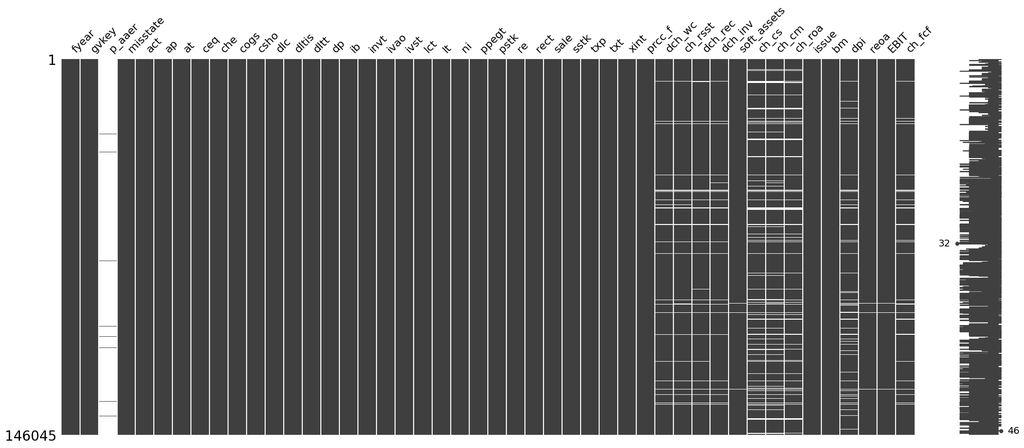

```python
# matrix missing
msno.matrix(data)
```

```python
#Verifico los datos faltantes del dataset o nulos
data.isnull().sum()
```

```
fyear               0
gvkey               0
p_aaer         145081
misstate            0
act                 0
ap                  0
at                  0
ceq                 0
che                 0
cogs                0
csho                0
dlc                 0
dltis               0
dltt                0
dp                  0
ib                  0
invt                0
ivao                0
ivst                0
lct                 0
lt                  0
ni                  0
ppegt               0
pstk                0
re                  0
rect                0
sale                0
sstk                0
txp                 0
txt                 0
xint                0
prcc_f              0
dch_wc           4759
ch_rsst          4851
dch_rec          4743
dch_inv          4615
soft_assets       592
ch_cs           15918
ch_cm           17107
ch_roa          12678
issue               0
bm                 18
dpi              9228
reoa              591
EBIT              591
ch_fcf           5407
dtype: int64
```

```python
# explorando la cantidad de valores perdidos en las variables
data.isna().sum()/data.shape[0]*100
```

```
fyear           0.000000
gvkey           0.000000
p_aaer         99.339929
misstate        0.000000
act             0.000000
ap              0.000000
at              0.000000
ceq             0.000000
che             0.000000
cogs            0.000000
csho            0.000000
dlc             0.000000
dltis           0.000000
dltt            0.000000
dp              0.000000
ib              0.000000
invt            0.000000
ivao            0.000000
ivst            0.000000
lct             0.000000
lt              0.000000
ni              0.000000
ppegt           0.000000
pstk            0.000000
re              0.000000
rect            0.000000
sale            0.000000
sstk            0.000000
txp             0.000000
txt             0.000000
xint            0.000000
prcc_f          0.000000
dch_wc          3.258585
ch_rsst         3.321579
dch_rec         3.247629
dch_inv         3.159985
soft_assets     0.405355
ch_cs          10.899380
ch_cm          11.713513
ch_roa          8.680886
issue           0.000000
bm              0.012325
dpi             6.318600
reoa            0.404670
EBIT            0.404670
ch_fcf          3.702284
dtype: float64
```

Columna "p_aaer": Esta columna tiene un alto porcentaje de valores perdidos (99.34%). Dado que la mayoría de los datos en esta columna son valores perdidos, es posible que desees considerar eliminarla por completo, ya que es poco probable que proporcione información útil para tu análisis.

Columnas con Valores Perdidos Moderados: Algunas columnas, como "dch_wc", "ch_rsst", "dch_rec", "dch_inv", "ch_cs", "ch_cm", "ch_roa" y "ch_fcf", tienen porcentajes moderados de valores perdidos que oscilan entre el 3% y el 11%. Puedes considerar diferentes enfoques para manejar estos valores perdidos, como la imputación, dependiendo de la importancia de estas columnas para tu análisis.

Otras Columnas: Las columnas restantes no tienen valores perdidos o tienen porcentajes muy bajos de valores perdidos.

```python
data.isin([0]).sum()
```

```
fyear               0
gvkey               0
p_aaer              0
misstate       145081
act               847
ap               1403
at                591
ceq                78
che              4774
cogs             8302
csho               18
dlc             35443
dltis           71251
dltt            39430
dp               4401
ib                133
invt            39785
ivao            97276
ivst            92420
lct               145
lt                126
ni                 63
ppegt            3884
pstk           125026
re                154
rect             7333
sale            10402
sstk            39246
txp             86648
txt             35309
xint            16568
prcc_f              3
dch_wc            108
ch_rsst            37
dch_rec          5203
dch_inv         35388
soft_assets         0
ch_cs              84
ch_cm             137
ch_roa              4
issue           19937
bm                 76
dpi                 0
reoa              149
EBIT               25
ch_fcf             16
dtype: int64
```

Al revisar los datos por sumas de ceros, observamos columnas de datos que pueden presentar ceros en su caracterización, por lo cual debemos establecer una política para lidiar con estos.

# Eliminar columnas

La variable "gvkey" identificador del fraude

La variable "p_aaer" se utiliza para gestionar el problema del fraude en serie. El fraude contable puede abarcar varios períodos consecutivos de presentación de informes, creando una situación del llamado “fraude en serie”

fyear año del fraude

misstate etiqueta que identifica el fraude: cero (no fraude) y uno (fraude)

```python
data = data.drop(['gvkey', 'p_aaer', 'fyear', 'misstate'], axis='columns')
data.head(10)
```

|  | act | ap | at | ceq | che | cogs | csho | dlc | dltis | dltt | ... | soft_assets | ch_cs | ch_cm | ch_roa | issue | bm | dpi | reoa | EBIT | ch_fcf |
| --- | --- | --- | --- | --- | --- | --- | --- | --- | --- | --- | --- | --- | --- | --- | --- | --- | --- | --- | --- | --- | --- |
| 0 | 10.047 | 3.736 | 32.335 | 6.262 | 0.002 | 30.633 | 2.526 | 3.283 | 32.853 | 17.691 | ... | 0.312448 | 0.095082 | 0.082631 | -0.019761 | 1 | 0.413170 | 0.873555 | 0.167620 | 0.161961 | -0.042140 |
| 1 | 1.247 | 0.803 | 7.784 | 0.667 | 0.171 | 1.125 | 3.556 | 0.021 | 2.017 | 5.871 | ... | 0.315904 | 0.188832 | -0.211389 | -0.117832 | 1 | 0.157887 | 0.745139 | -0.428957 | -0.157888 | 0.100228 |
| 2 | 55.040 | 3.601 | 118.120 | 44.393 | 3.132 | 107.343 | 3.882 | 6.446 | 6.500 | 37.603 | ... | 0.605342 | 0.097551 | -0.105780 | 0.091206 | 1 | 2.231337 | 1.015131 | 0.394768 | 0.063681 | 0.066348 |
| 3 | 24.684 | 3.948 | 34.591 | 7.751 | 0.411 | 31.214 | 4.755 | 8.791 | 0.587 | 8.906 | ... | 0.793068 | -0.005725 | -0.249704 | 0.017545 | 1 | 1.043582 | 1.026261 | 0.094822 | 0.088347 | -0.017358 |
| 4 | 17.325 | 3.520 | 27.542 | -12.142 | 1.017 | 32.662 | 6.735 | 32.206 | 0.000 | 0.266 | ... | 0.869182 | -0.231536 | -1.674893 | -0.466667 | 0 | -1.602508 | 0.598443 | -0.942379 | -0.700821 | 0.130349 |
| 5 | 148.396 | 24.301 | 328.495 | 111.015 | 8.478 | 153.262 | 11.235 | 44.339 | 0.273 | 101.386 | ... | 0.688689 | 0.040056 | 0.092675 | 0.003067 | 1 | 0.389406 | 0.851688 | 0.191741 | 0.105527 | -0.034367 |
| 6 | 637.880 | 199.012 | 1011.901 | 324.132 | 113.271 | 1185.288 | 28.489 | 22.444 | 60.769 | 195.221 | ... | 0.754448 | -0.033881 | -0.372440 | -0.040405 | 1 | 1.379084 | 0.955720 | -0.038167 | 0.055174 | -0.042160 |
| 7 | 396.594 | 92.140 | 677.736 | 183.566 | 50.125 | 596.137 | 46.758 | 80.971 | 1.146 | 92.131 | ... | 0.819713 | 0.047023 | -0.061932 | -0.108796 | 1 | 1.847471 | 0.964188 | -0.192385 | -0.031264 | -0.041039 |
| 8 | 2657.800 | 966.300 | 13353.600 | 3727.400 | 949.300 | 10908.200 | 62.300 | 1319.100 | 2264.600 | 3271.900 | ... | 0.243882 | 0.117693 | -0.369057 | -0.047424 | 1 | 1.236793 | 0.996031 | 0.181389 | 0.022773 | -0.038199 |
| 9 | 0.004 | 0.000 | 0.126 | -0.778 | 0.000 | 0.000 | 9.928 | 0.624 | 0.132 | 0.226 | ... | 0.809524 | NaN | NaN | -1.520085 | 1 | -0.156728 | NaN | -22.174603 | -7.016393 | 0.118902 |

10 rows × 42 columns

# Técnicas de imputación de datos

Imputación Basada en Reglas de Negocio: Reemplazar los valores faltantes con cero

```python
# Lista de las columnas que tienen valores perdidos
columnas_imputar = ['dch_wc', 'ch_rsst', 'dch_rec', 'dch_inv', 'ch_cs', 'ch_cm', 'ch_roa', 'bm', 'reoa', 'EBIT', 'ch_fcf', 'soft_assets', 'dpi']
#Reemplazar los valores nulos con -1 en las columnas seleccionados
data[columnas_imputar] = data[columnas_imputar].fillna(0)
```

```python
# Después de la imputación
print(data[columnas_imputar].isnull().sum())
```

```
dch_wc         0
ch_rsst        0
dch_rec        0
dch_inv        0
ch_cs          0
ch_cm          0
ch_roa         0
bm             0
reoa           0
EBIT           0
ch_fcf         0
soft_assets    0
dpi            0
dtype: int64
```

```python
# Itera a través de las columnas del DataFrame y verifica el equilibrio
for columna in data.columns:
    if data[columna].dtype == 'object':
        # Si es una variable categórica, verifica el equilibrio de las categorías
        counts = data[columna].value_counts()
        print(f"Variable categórica: {columna}")
        print(counts)
    elif data[columna].dtype in ['int64', 'float64']:
        # Si es una variable numérica, puedes calcular estadísticas descriptivas
        descripcion = data[columna].describe()
        print(f"Variable numérica: {columna}")
        print(descripcion)
    print('-' * 40)
```

```
Variable numérica: act
count    146045.000000
mean        737.847759
std        3744.542368
min          -0.254000
25%           8.277000
50%          47.501000
75%         249.832000
max      152629.000000
Name: act, dtype: float64
----------------------------------------
Variable numérica: ap
count    146045.000000
mean        181.993488
std        1047.546104
min           0.000000
25%           1.151000
50%           6.462000
75%          42.259000
max       39903.000000
Name: ap, dtype: float64
----------------------------------------
Variable numérica: at
count    146045.000000
mean       2374.041576
std       11957.736980
min           0.000000
25%          18.281000
50%         105.346000
75%         672.929000
max      410074.000000
Name: at, dtype: float64
----------------------------------------
Variable numérica: ceq
count    146045.000000
mean        887.126243
std        5056.948150
min      -25560.000000
25%           6.337000
50%          47.308000
```

[output cut: 407 more lines]

```
75%           0.107747
max           0.550619
Name: EBIT, dtype: float64
----------------------------------------
Variable numérica: ch_fcf
count    146045.000000
mean         -0.008515
std           0.537974
min          -2.980601
25%          -0.116775
50%          -0.021442
75%           0.055781
max           4.061810
Name: ch_fcf, dtype: float64
----------------------------------------
```

```python
data.isna().sum()
```

```
act            0
ap             0
at             0
ceq            0
che            0
cogs           0
csho           0
dlc            0
dltis          0
dltt           0
dp             0
ib             0
invt           0
ivao           0
ivst           0
lct            0
lt             0
ni             0
ppegt          0
pstk           0
re             0
rect           0
sale           0
sstk           0
txp            0
txt            0
xint           0
prcc_f         0
dch_wc         0
ch_rsst        0
dch_rec        0
dch_inv        0
soft_assets    0
ch_cs          0
ch_cm          0
ch_roa         0
issue          0
bm             0
dpi            0
reoa           0
EBIT           0
ch_fcf         0
dtype: int64
```

# Mezclar el dataset

```python
#Mezclar el dataset
data = data.sample(frac=1).reset_index(drop=True)
data.head(10)
```

|  | act | ap | at | ceq | che | cogs | csho | dlc | dltis | dltt | ... | soft_assets | ch_cs | ch_cm | ch_roa | issue | bm | dpi | reoa | EBIT | ch_fcf |
| --- | --- | --- | --- | --- | --- | --- | --- | --- | --- | --- | --- | --- | --- | --- | --- | --- | --- | --- | --- | --- | --- |
| 0 | 772.428 | 222.742 | 1171.259 | 425.129 | 68.223 | 1529.816 | 42.896 | 105.000 | 0.000 | 198.823 | ... | 0.817024 | 0.031671 | -0.033511 | 0.002782 | 0 | 0.574866 | 1.137261 | 0.258787 | 0.053119 | 0.022448 |
| 1 | 2213.722 | 909.649 | 5169.235 | 1609.440 | 58.585 | 4120.035 | 107.021 | 396.467 | 14.798 | 648.326 | ... | 0.804477 | 0.054078 | -0.069339 | -0.002305 | 1 | 0.179565 | 1.110650 | 0.784573 | 0.140101 | -0.018676 |
| 2 | 143.643 | 4.282 | 152.399 | 116.996 | 105.213 | 103.561 | 38.689 | 0.000 | 0.000 | 0.000 | ... | 0.275382 | 0.086238 | 0.123431 | 0.080787 | 1 | 0.233876 | 1.190027 | 0.512549 | 0.190821 | 0.063667 |
| 3 | 93.930 | 12.906 | 101.688 | 16.507 | 2.689 | 443.587 | 6.483 | 41.251 | 0.000 | 0.000 | ... | 0.899929 | -0.224181 | 0.998438 | -0.040086 | 1 | 0.391723 | 0.638687 | -0.234905 | -0.178999 | 0.000000 |
| 4 | 13479.000 | 4717.000 | 40125.000 | 18889.000 | 545.000 | 44693.000 | 1623.000 | 1042.000 | 998.000 | 8707.000 | ... | 0.361869 | 0.029001 | 0.056260 | 0.017548 | 1 | 0.316517 | 1.031525 | 0.384798 | 0.144698 | 0.010889 |
| 5 | 2519.200 | 1336.200 | 22817.700 | 6992.200 | 92.400 | 3335.300 | 270.172 | 2117.800 | 649.100 | 4586.100 | ... | 0.236246 | 0.048917 | 0.029116 | -0.070725 | 1 | 0.363236 | 1.002858 | 0.123023 | 0.032015 | 0.062065 |
| 6 | 67.062 | 35.230 | 972.376 | 410.634 | 19.887 | 139.601 | 95.213 | 103.765 | 242.582 | 288.632 | ... | 0.342024 | 0.449550 | 6.077445 | 0.176458 | 1 | 0.070847 | 0.915774 | -0.822903 | -0.205097 | -0.300970 |
| 7 | 44.056 | 15.843 | 162.765 | 100.564 | 15.294 | 79.061 | 27.470 | 23.470 | 0.000 | 2.313 | ... | 0.821159 | 3.252260 | -4.320919 | -0.769553 | 1 | 4.505682 | 0.929954 | -2.149811 | -1.709127 | -0.124742 |
| 8 | 3.809 | 1.655 | 5.038 | 3.211 | 1.281 | 3.602 | 18.046 | 0.138 | 0.000 | 0.034 | ... | 0.668718 | 0.118145 | -0.277288 | -0.105547 | 1 | 0.113878 | 0.847341 | -2.326320 | -0.419809 | 0.082973 |
| 9 | 1.569 | 2.210 | 7.461 | 2.680 | 0.156 | 3.998 | 4.327 | 0.000 | 1.775 | 2.522 | ... | 0.311218 | -0.283918 | -0.587292 | -0.267133 | 1 | 4.424048 | 1.165408 | -1.865031 | -0.089130 | -0.263592 |

10 rows × 42 columns

## 2. Análisis de patrones de características individuales mediante visualización

- Para instalar seaborn usamos pip que es el administrador de paquetes de python.

### calcular la correlación entre variables de tipo “int64” o “float64” utilizando el método “corr”:

```python
corr = data.corr()
# Aplica un mapa de colores a la tabla
corr.style.background_gradient("RdYlGn", low=-1, high=1)

# Imprime la tabla
print(corr)
```

```
                  act        ap        at       ceq       che      cogs  \
act          1.000000  0.837398  0.878315  0.781781  0.824967  0.775588
ap           0.837398  1.000000  0.814882  0.714306  0.606061  0.893112
at           0.878315  0.814882  1.000000  0.922935  0.696252  0.766761
ceq          0.781781  0.714306  0.922935  1.000000  0.674905  0.688589
che          0.824967  0.606061  0.696252  0.674905  1.000000  0.499444
cogs         0.775588  0.893112  0.766761  0.688589  0.499444  1.000000
csho         0.380716  0.320160  0.422942  0.431327  0.387291  0.277419
dlc          0.756073  0.626860  0.732312  0.589192  0.504066  0.596105
dltis        0.443239  0.432536  0.502433  0.410146  0.295679  0.486693
dltt         0.704906  0.646234  0.869181  0.688693  0.540087  0.587696
dp           0.734202  0.727898  0.897125  0.828959  0.581175  0.670086
ib           0.594168  0.561907  0.620597  0.664445  0.559258  0.549225
invt         0.786498  0.767760  0.695842  0.630951  0.481461  0.822406
ivao         0.527799  0.419550  0.493431  0.436267  0.446340  0.362806
ivst         0.531702  0.309106  0.398065  0.421553  0.825681  0.215141
lct          0.942648  0.886424  0.911807  0.779619  0.695049  0.826275
lt           0.873467  0.816551  0.966151  0.795434  0.655144  0.757834
ni           0.555981  0.521918  0.580658  0.624362  0.530992  0.507526
ppegt        0.707443  0.737856  0.892599  0.819582  0.511092  0.729575
pstk         0.087006  0.087013  0.119306  0.071435  0.073945  0.076975
re           0.613358  0.601986  0.645504  0.715160  0.462425  0.635809
rect         0.921919  0.799190  0.824882  0.698456  0.627657  0.726937
sale         0.833866  0.909881  0.838974  0.765433  0.582301  0.980731
sstk         0.250608  0.173988  0.275601  0.286305  0.269170  0.149808
txp          0.567046  0.541236  0.638569  0.631110  0.459817  0.536944
txt          0.594196  0.627781  0.644187  0.665308  0.481826  0.633136
xint         0.581960  0.573818  0.776689  0.616064  0.447832  0.524890
prcc_f       0.149363  0.130508  0.140180  0.133828  0.127099  0.123958
dch_wc       0.009335  0.005334  0.006868  0.007288  0.001843  0.006515
ch_rsst      0.004418  0.002657  0.005809  0.014202  0.005860  0.001424
dch_rec     -0.005907 -0.003290 -0.012733 -0.009330 -0.009777 -0.007268
dch_inv     -0.002950 -0.000248 -0.009488 -0.006022 -0.010534 -0.000521
soft_assets  0.042000  0.031988  0.013128  0.005854  0.002620  0.024310
ch_cs       -0.008174 -0.007799 -0.007332 -0.004513 -0.004849 -0.006934
ch_cm        0.007281  0.006339  0.007360  0.006702  0.004926  0.005824
ch_roa       0.004458  0.003628  0.003653  0.003698  0.005213  0.003052
issue        0.063094  0.056821  0.065528  0.056817  0.049545  0.054329
bm           0.010422  0.010727  0.016244  0.031305  0.004006  0.009778
dpi          0.008525  0.006644  0.008322  0.006685  0.007752  0.005856
```

[output cut: 122 more lines]

```
ch_rsst      0.315202  0.438963 -0.690730
dch_rec      0.101144  0.119219 -0.175720
dch_inv      0.087829  0.099924 -0.163581
soft_assets  0.031555  0.050370  0.015568
ch_cs        0.047889  0.033019 -0.064673
ch_cm        0.020080  0.027951 -0.010531
ch_roa       0.146317  0.334876  0.135155
issue        0.144267  0.080323 -0.137191
bm           0.298402  0.239431 -0.196553
dpi          0.114768  0.134974 -0.076366
reoa         1.000000  0.732063 -0.349606
EBIT         0.732063  1.000000 -0.258254
ch_fcf      -0.349606 -0.258254  1.000000

[42 rows x 42 columns]
```

```python
# Visualizar la relación entre todas las variables utilizando una matriz de diagramas de dispersión
#sns.pairplot(data)
```

```python
#Guardamos el dataset- Hacemos una clasificacion binaria.
data.to_csv('fraude1.csv', index=False)
```

# Nuevo conjunto de datos fraude1

```python
data1 = pd.read_csv('fraude1.csv')
data1.sample(10)
```

|  | act | ap | at | ceq | che | cogs | csho | dlc | dltis | dltt | ... | soft_assets | ch_cs | ch_cm | ch_roa | issue | bm | dpi | reoa | EBIT | ch_fcf |
| --- | --- | --- | --- | --- | --- | --- | --- | --- | --- | --- | --- | --- | --- | --- | --- | --- | --- | --- | --- | --- | --- |
| 93524 | 35.775 | 5.691 | 54.770 | 25.210 | 3.093 | 46.171 | 2.928 | 4.627 | 0.000 | 7.252 | ... | 0.676757 | 0.011434 | 0.042749 | 0.002424 | 1 | 0.637776 | 1.025961 | 0.486617 | 0.166861 | -0.049413 |
| 113522 | 449.719 | 207.568 | 1475.862 | 649.665 | 0.194 | 1510.596 | 85.375 | 15.542 | 2.064 | 309.208 | ... | 0.432912 | 0.007621 | -0.214585 | -0.033446 | 1 | 0.661700 | 0.977672 | 0.365874 | 0.061904 | -0.000922 |
| 66775 | 151.087 | 59.226 | 240.885 | -276.967 | 35.437 | 429.376 | 39.516 | 0.000 | 0.000 | 367.075 | ... | 0.685875 | 0.053260 | 0.414342 | 0.110690 | 1 | -0.189432 | 1.091394 | -0.982921 | 0.550619 | -0.022234 |
| 4227 | 103.797 | 21.787 | 441.357 | 130.677 | 25.437 | 259.273 | 46.235 | 15.005 | 0.701 | 211.259 | ... | 0.817560 | -0.060733 | -0.040210 | -0.217203 | 1 | 0.615766 | 0.937772 | 0.070018 | -0.115671 | 0.037956 |
| 50862 | 10.895 | 0.525 | 12.105 | 9.807 | 6.684 | 3.682 | 13.452 | 0.000 | 0.000 | 0.000 | ... | 0.419909 | -0.309854 | 0.685684 | 0.210968 | 1 | 0.597571 | 0.976306 | -3.612970 | 0.135233 | -0.078060 |
| 4626 | 941.708 | 220.031 | 2785.957 | 1650.632 | 277.666 | 1545.332 | 158.306 | 5.888 | 4.692 | 493.754 | ... | 0.595110 | 0.030414 | -0.378967 | -0.003222 | 1 | 0.305146 | 0.937128 | 0.365112 | 0.104890 | -0.022136 |
| 78584 | 170.800 | 43.800 | 336.080 | 57.593 | 1.392 | 623.051 | 7.886 | 11.904 | 5.089 | 184.744 | ... | 0.581722 | 0.066777 | 0.199867 | 0.327019 | 1 | 0.138633 | 1.327241 | 0.095834 | 0.261551 | -0.065505 |
| 91070 | 2519.000 | 766.000 | 21838.000 | 7729.000 | 86.000 | 5730.000 | 401.018 | 967.000 | 426.000 | 5504.000 | ... | 0.212245 | 0.014252 | 0.122974 | -0.001405 | 1 | 0.431898 | 1.017679 | 0.192188 | 0.101978 | -0.016537 |
| 2363 | 1232.416 | 365.334 | 3427.298 | 953.740 | 613.123 | 2012.076 | 216.702 | 61.350 | 380.000 | 1591.390 | ... | 0.235644 | 0.108562 | 0.200218 | 0.019453 | 1 | 0.717971 | 0.996183 | -0.188954 | 0.069603 | -0.013161 |
| 40916 | 761.845 | 115.825 | 1321.694 | 1169.131 | 754.350 | 0.144 | 75.694 | 0.000 | 0.000 | 0.000 | ... | 0.040397 | 0.000000 | 0.000000 | 0.000000 | 1 | 0.794930 | 0.000000 | -0.000369 | 0.009225 | -0.905126 |

10 rows × 42 columns

# Técnicas de escalado

La elección entre las técnicas de escalado de características como RobustScaler, StandardScaler y MinMaxScaler depende de la naturaleza de tus datos y los requisitos de tu modelo de machine learning. Cada técnica tiene sus propias características y es adecuada para diferentes situaciones. Aquí hay una guía general sobre cuándo usar cada una:

**RobustScaler**:

- *Cuándo usarlo*: Utiliza RobustScaler cuando tus datos contienen valores atípicos o anomalías. RobustScaler es resistente a los valores extremos y utiliza estadísticas robustas como la mediana y el rango intercuartílico para escalar los datos.
- *Ventajas*: Bueno para datos con valores atípicos, ya que no se ven afectados por ellos.
- *Consideraciones*: No restringe los datos a un rango específico como MinMaxScaler, por lo que los datos pueden tener una mayor dispersión.

**StandardScaler (Z-Score Scaling)**:

- *Cuándo usarlo*: Utiliza StandardScaler cuando tus datos sigan una distribución normal o aproximadamente normal. Es una opción sólida para muchas técnicas de machine learning, como regresión lineal, SVM y algoritmos basados en gradiente.
- *Ventajas*: Transforma los datos para que tengan una media de cero y una desviación estándar de uno, lo que puede ser beneficioso para algoritmos que asumen normalidad.
- *Consideraciones*: Puede verse afectado por valores atípicos y no es adecuado para datos que no siguen una distribución normal.

**MinMaxScaler**:

- *Cuándo usarlo*: Utiliza MinMaxScaler cuando desees que tus datos se escalen a un rango específico, generalmente entre 0 y 1. Es útil para algoritmos que requieren que los datos estén en un rango acotado, como las redes neuronales y los algoritmos de clustering basados en distancia.
- *Ventajas*: Escala los datos al rango deseado, lo que puede mejorar la convergencia en algunos algoritmos.
- *Consideraciones*: Sensible a valores atípicos si los valores extremos están presentes.

La elección de la técnica depende de la naturaleza de tus datos y del algoritmo que planeas usar. Aquí hay algunas pautas generales:

- Si tienes valores atípicos en tus datos y deseas ser resistente a ellos, considera RobustScaler.
- Si tus datos siguen una distribución normal y planeas utilizar algoritmos que asumen normalidad, elige StandardScaler.
- Si deseas que tus datos estén en un rango específico, como [0, 1], usa MinMaxScaler.

```python
pip install -U scikit-learn
```

# MinMaxScaler

```python
from sklearn import preprocessing
fraud_value = data1.copy().values
min_max_scaler = preprocessing.MinMaxScaler()
fraud_scaled = min_max_scaler.fit_transform(fraud_value)
fraud_df_scaled = pd.DataFrame(fraud_scaled, columns=data1.columns)
fraud_df_scaled
```

|  | act | ap | at | ceq | che | cogs | csho | dlc | dltis | dltt | ... | soft_assets | ch_cs | ch_cm | ch_roa | issue | bm | dpi | reoa | EBIT | ch_fcf |
| --- | --- | --- | --- | --- | --- | --- | --- | --- | --- | --- | --- | --- | --- | --- | --- | --- | --- | --- | --- | --- | --- |
| 0 | 0.005062 | 0.005582 | 0.002856 | 0.083825 | 0.001192 | 0.004349 | 0.000429 | 1.390665e-03 | 0.000104 | 1.653084e-03 | ... | 0.822288 | 0.405110 | 0.510592 | 0.508426 | 0.0 | 0.635593 | 0.281747 | 0.994145 | 0.934254 | 0.426424 |
| 1 | 0.014506 | 0.022797 | 0.012606 | 0.087645 | 0.001080 | 0.010288 | 0.001069 | 5.248443e-03 | 0.000183 | 5.390409e-03 | ... | 0.809660 | 0.406503 | 0.509536 | 0.506882 | 1.0 | 0.602574 | 0.275155 | 1.000000 | 0.945749 | 0.420584 |
| 2 | 0.000943 | 0.000107 | 0.000372 | 0.082831 | 0.001624 | 0.001078 | 0.000387 | 9.132653e-07 | 0.000104 | 0.000000e+00 | ... | 0.277157 | 0.408503 | 0.515217 | 0.532113 | 1.0 | 0.607110 | 0.294820 | 0.996971 | 0.952452 | 0.432276 |
| 3 | 0.000617 | 0.000323 | 0.000248 | 0.082506 | 0.000428 | 0.001858 | 0.000065 | 5.469004e-04 | 0.000104 | 0.000000e+00 | ... | 0.905727 | 0.389203 | 0.541003 | 0.495409 | 1.0 | 0.620295 | 0.158229 | 0.988647 | 0.903579 | 0.423236 |
| 4 | 0.088314 | 0.118212 | 0.097848 | 0.143387 | 0.006753 | 0.103326 | 0.016215 | 1.379254e-02 | 0.005390 | 7.239304e-02 | ... | 0.364201 | 0.404944 | 0.513238 | 0.512910 | 1.0 | 0.614013 | 0.255552 | 0.995548 | 0.946356 | 0.424782 |
| ... | ... | ... | ... | ... | ... | ... | ... | ... | ... | ... | ... | ... | ... | ... | ... | ... | ... | ... | ... | ... | ... |
| 146040 | 0.000002 | 0.000000 | 0.000000 | 0.082453 | 0.000397 | 0.000841 | 0.000547 | 1.177980e-06 | 0.000104 | 0.000000e+00 | ... | 0.000000 | 0.403141 | 0.511580 | 0.507582 | 0.0 | 0.587509 | 0.000000 | 0.991263 | 0.927234 | 1.000000 |
| 146041 | 0.000011 | 0.000005 | 0.000005 | 0.082459 | 0.000408 | 0.000843 | 0.000072 | 9.132653e-07 | 0.000104 | 0.000000e+00 | ... | 0.462055 | 0.393672 | 0.429366 | 0.425316 | 1.0 | 0.592820 | 0.329706 | 0.912986 | 0.824383 | 0.438148 |
| 146042 | 0.002691 | 0.000143 | 0.004488 | 0.083102 | 0.003450 | 0.002099 | 0.000778 | 9.979078e-04 | 0.000486 | 1.206764e-02 | ... | 0.126444 | 0.382866 | 0.500187 | 0.437492 | 1.0 | 0.637836 | 0.126264 | 0.988433 | 0.899853 | 0.415105 |
| 146043 | 0.004857 | 0.003133 | 0.002793 | 0.084669 | 0.004138 | 0.002892 | 0.000595 | 1.078434e-03 | 0.000165 | 8.180820e-04 | ... | 0.517150 | 0.397328 | 0.509358 | 0.525096 | 1.0 | 0.683217 | 0.251911 | 0.995803 | 0.931467 | 0.423899 |
| 146044 | 0.001158 | 0.001645 | 0.000469 | 0.082825 | 0.000641 | 0.001817 | 0.000166 | 1.138273e-06 | 0.000104 | 2.411161e-07 | ... | 0.817199 | 0.410721 | 0.501245 | 0.547454 | 1.0 | 0.626177 | 0.201768 | 0.991322 | 0.938897 | 0.440834 |

146045 rows × 42 columns

```python
fraud_df_scaled.info()
```

```
<class 'pandas.core.frame.DataFrame'>
RangeIndex: 146045 entries, 0 to 146044
Data columns (total 42 columns):
 #   Column       Non-Null Count   Dtype
---  ------       --------------   -----
 0   act          146045 non-null  float64
 1   ap           146045 non-null  float64
 2   at           146045 non-null  float64
 3   ceq          146045 non-null  float64
 4   che          146045 non-null  float64
 5   cogs         146045 non-null  float64
 6   csho         146045 non-null  float64
 7   dlc          146045 non-null  float64
 8   dltis        146045 non-null  float64
 9   dltt         146045 non-null  float64
```

[output cut: 34 more lines]

# RobustScaler

```python
from sklearn import preprocessing
fraud_value_1 = data1.copy().values
robust_scaler = preprocessing.RobustScaler()
fraud_scaled_1 = robust_scaler.fit_transform(fraud_value_1)
fraud_df_scaled_1 = pd.DataFrame(fraud_scaled_1, columns=data1.columns)
fraud_df_scaled_1
```

|  | act | ap | at | ceq | che | cogs | csho | dlc | dltis | dltt | ... | soft_assets | ch_cs | ch_cm | ch_roa | issue | bm | dpi | reoa | EBIT | ch_fcf |
| --- | --- | --- | --- | --- | --- | --- | --- | --- | --- | --- | --- | --- | --- | --- | --- | --- | --- | --- | --- | --- | --- |
| 0 | 3.001085 | 5.261263 | 1.628223 | 1.424611 | 0.995063 | 4.034689 | 0.391914 | 8.133496 | -0.002533 | 1.539862 | ... | 0.640194 | -0.028117 | -0.109035 | 0.033652 | -1.0 | 0.216335 | 0.650067 | 0.237297 | 0.042723 | 0.254358 |
| 1 | 8.967817 | 21.971076 | 7.735285 | 5.890170 | 0.832099 | 11.113047 | 1.626511 | 31.008005 | 0.592409 | 5.101353 | ... | 0.612889 | 0.056639 | -0.225611 | -0.027881 | 0.0 | -0.427713 | 0.551601 | 0.708807 | 0.413470 | 0.016034 |
| 2 | 0.398013 | -0.053031 | 0.071875 | 0.262765 | 1.620507 | 0.137125 | 0.310916 | -0.106969 | -0.002533 | -0.035448 | ... | -0.538529 | 0.178287 | 0.401610 | 0.977333 | 0.0 | -0.339227 | 0.845320 | 0.464864 | 0.629659 | 0.493228 |
| 3 | 0.192209 | 0.156758 | -0.005588 | -0.116138 | -0.113016 | 1.066323 | -0.309145 | 3.130435 | -0.002533 | -0.035448 | ... | 0.820612 | -0.995906 | 3.248647 | -0.484949 | 0.0 | -0.082053 | -1.194809 | -0.205433 | -0.946643 | 0.124264 |
| 4 | 55.604310 | 114.589326 | 61.131561 | 71.044425 | 9.056626 | 121.987834 | 30.813631 | 81.669832 | 40.121296 | 68.951653 | ... | -0.350316 | -0.038217 | 0.183055 | 0.212287 | 0.0 | -0.204583 | 0.258812 | 0.350299 | 0.433064 | 0.187366 |
| ... | ... | ... | ... | ... | ... | ... | ... | ... | ... | ... | ... | ... | ... | ... | ... | ... | ... | ... | ... | ... | ... |
| 146040 | -0.196647 | -0.157196 | -0.160920 | -0.178624 | -0.158483 | -0.145878 | 0.619638 | -0.105399 | -0.002533 | -0.035448 | ... | -1.137817 | -0.147917 | 0.000000 | 0.000000 | -1.0 | -0.721544 | -3.558144 | 0.005223 | -0.183689 | 23.663364 |
| 146041 | -0.190607 | -0.151893 | -0.157503 | -0.171117 | -0.141693 | -0.143766 | -0.296034 | -0.106969 | -0.002533 | -0.035448 | ... | -0.138729 | -0.723979 | -9.077312 | -3.277471 | 0.0 | -0.617954 | 1.366392 | -6.298242 | -3.500967 | 0.732859 |
| 146042 | 1.502366 | -0.018366 | 2.650620 | 0.579450 | 4.268439 | 1.354060 | 1.065056 | 5.804662 | 2.892172 | 11.464433 | ... | -0.864411 | -1.381448 | -1.257842 | -2.792377 | 0.0 | 0.260089 | -1.672255 | -0.222696 | -1.066836 | -0.207596 |
| 146043 | 2.870957 | 2.884232 | 1.588733 | 2.411655 | 5.266308 | 2.298766 | 0.713015 | 6.282138 | 0.457042 | 0.744145 | ... | -0.019599 | -0.501564 | -0.245314 | 0.697780 | 0.0 | 1.145247 | 0.204427 | 0.370814 | -0.047160 | 0.151322 |
| 146044 | 0.533862 | 1.439233 | 0.132870 | 0.255880 | 0.196392 | 1.017921 | -0.114093 | -0.105635 | -0.002533 | -0.035219 | ... | 0.629190 | 0.313264 | -1.141050 | 1.588514 | 0.0 | 0.032676 | -0.544515 | 0.009956 | 0.192463 | 0.842465 |

146045 rows × 42 columns

```python
fraud_df_scaled_1.head()
```

|  | act | ap | at | ceq | che | cogs | csho | dlc | dltis | dltt | ... | soft_assets | ch_cs | ch_cm | ch_roa | issue | bm | dpi | reoa | EBIT | ch_fcf |
| --- | --- | --- | --- | --- | --- | --- | --- | --- | --- | --- | --- | --- | --- | --- | --- | --- | --- | --- | --- | --- | --- |
| 0 | 3.001085 | 5.261263 | 1.628223 | 1.424611 | 0.995063 | 4.034689 | 0.391914 | 8.133496 | -0.002533 | 1.539862 | ... | 0.640194 | -0.028117 | -0.109035 | 0.033652 | -1.0 | 0.216335 | 0.650067 | 0.237297 | 0.042723 | 0.254358 |
| 1 | 8.967817 | 21.971076 | 7.735285 | 5.890170 | 0.832099 | 11.113047 | 1.626511 | 31.008005 | 0.592409 | 5.101353 | ... | 0.612889 | 0.056639 | -0.225611 | -0.027881 | 0.0 | -0.427713 | 0.551601 | 0.708807 | 0.413470 | 0.016034 |
| 2 | 0.398013 | -0.053031 | 0.071875 | 0.262765 | 1.620507 | 0.137125 | 0.310916 | -0.106969 | -0.002533 | -0.035448 | ... | -0.538529 | 0.178287 | 0.401610 | 0.977333 | 0.0 | -0.339227 | 0.845320 | 0.464864 | 0.629659 | 0.493228 |
| 3 | 0.192209 | 0.156758 | -0.005588 | -0.116138 | -0.113016 | 1.066323 | -0.309145 | 3.130435 | -0.002533 | -0.035448 | ... | 0.820612 | -0.995906 | 3.248647 | -0.484949 | 0.0 | -0.082053 | -1.194809 | -0.205433 | -0.946643 | 0.124264 |
| 4 | 55.604310 | 114.589326 | 61.131561 | 71.044425 | 9.056626 | 121.987834 | 30.813631 | 81.669832 | 40.121296 | 68.951653 | ... | -0.350316 | -0.038217 | 0.183055 | 0.212287 | 0.0 | -0.204583 | 0.258812 | 0.350299 | 0.433064 | 0.187366 |

5 rows × 42 columns

# StandardScaler

```python
from sklearn import preprocessing
fraud_value_2 = data1.copy().values
standard_scaler = preprocessing.StandardScaler()
fraud_scaled_2 = standard_scaler.fit_transform(fraud_value_2)
fraud_df_scaled_2 = pd.DataFrame(fraud_scaled_2, columns=data1.columns)
fraud_df_scaled_2
```

|  | act | ap | at | ceq | che | cogs | csho | dlc | dltis | dltt | ... | soft_assets | ch_cs | ch_cm | ch_roa | issue | bm | dpi | reoa | EBIT | ch_fcf |
| --- | --- | --- | --- | --- | --- | --- | --- | --- | --- | --- | --- | --- | --- | --- | --- | --- | --- | --- | --- | --- | --- |
| 0 | 0.009235 | 0.038899 | -0.100586 | -0.091359 | -0.113067 | 0.028909 | -0.100039 | -0.021726 | -0.123620 | -0.127620 | ... | 1.159223 | -0.101997 | 0.017512 | 0.033367 | -2.515020 | 0.082753 | 0.296705 | 0.266283 | 0.275194 | 0.057556 |
| 1 | 0.394141 | 0.694631 | 0.233757 | 0.142836 | -0.120311 | 0.358008 | 0.018519 | 0.263163 | -0.114533 | 0.041324 | ... | 1.113665 | -0.084854 | 0.004109 | 0.019345 | 0.397611 | -0.217951 | 0.247637 | 0.307018 | 0.357478 | -0.018887 |
| 2 | -0.158686 | -0.169646 | -0.185792 | -0.152292 | -0.085265 | -0.152303 | -0.107818 | -0.124357 | -0.123620 | -0.202347 | ... | -0.807459 | -0.060249 | 0.076222 | 0.248414 | 0.397611 | -0.176637 | 0.394004 | 0.285943 | 0.405460 | 0.134174 |
| 3 | -0.171962 | -0.161413 | -0.190033 | -0.172164 | -0.162323 | -0.109101 | -0.167362 | -0.084037 | -0.123620 | -0.202347 | ... | 1.460248 | -0.297743 | 0.403553 | -0.084812 | 0.397611 | -0.056563 | -0.622644 | 0.228035 | 0.055614 | 0.015828 |
| 4 | 3.402604 | 4.329186 | 3.157043 | 3.559842 | 0.245281 | 5.512986 | 2.821356 | 0.894128 | 0.489224 | 3.070147 | ... | -0.493429 | -0.104039 | 0.051094 | 0.074075 | 0.397611 | -0.113772 | 0.101732 | 0.276046 | 0.361827 | 0.036068 |
| ... | ... | ... | ... | ... | ... | ... | ... | ... | ... | ... | ... | ... | ... | ... | ... | ... | ... | ... | ... | ... | ... |
| 146040 | -0.197047 | -0.173734 | -0.198537 | -0.175441 | -0.164344 | -0.165461 | -0.078171 | -0.124337 | -0.123620 | -0.202347 | ... | -1.807362 | -0.126227 | 0.030048 | 0.025698 | -2.515020 | -0.355139 | -1.800355 | 0.246234 | 0.224945 | 7.566046 |
| 146041 | -0.196657 | -0.173526 | -0.198350 | -0.175047 | -0.163598 | -0.165362 | -0.166103 | -0.124357 | -0.123620 | -0.202347 | ... | -0.140398 | -0.242742 | -1.013594 | -0.721175 | 0.397611 | -0.306774 | 0.653668 | -0.298334 | -0.511295 | 0.211036 |
| 146042 | -0.087446 | -0.168286 | -0.044613 | -0.135684 | 0.032439 | -0.095723 | -0.035398 | -0.050731 | -0.079407 | 0.343165 | ... | -1.351188 | -0.375723 | -0.114569 | -0.610631 | 0.397611 | 0.103182 | -0.860568 | 0.226544 | 0.028938 | -0.090617 |
| 146043 | 0.000840 | -0.054381 | -0.102748 | -0.039594 | 0.076796 | -0.051800 | -0.069204 | -0.044784 | -0.116601 | -0.165366 | ... | 0.058369 | -0.197756 | 0.001844 | 0.184709 | 0.397611 | 0.516459 | 0.074631 | 0.277818 | 0.255246 | 0.024507 |
| 146044 | -0.149923 | -0.111086 | -0.182453 | -0.152653 | -0.148569 | -0.111351 | -0.148631 | -0.124340 | -0.123620 | -0.202336 | ... | 1.140864 | -0.032949 | -0.101141 | 0.387691 | 0.397611 | -0.002997 | -0.298586 | 0.246643 | 0.308428 | 0.246193 |

146045 rows × 42 columns

```python
fraud_df_scaled_2.head()
```

|  | act | ap | at | ceq | che | cogs | csho | dlc | dltis | dltt | ... | soft_assets | ch_cs | ch_cm | ch_roa | issue | bm | dpi | reoa | EBIT | ch_fcf |
| --- | --- | --- | --- | --- | --- | --- | --- | --- | --- | --- | --- | --- | --- | --- | --- | --- | --- | --- | --- | --- | --- |
| 0 | 0.009235 | 0.038899 | -0.100586 | -0.091359 | -0.113067 | 0.028909 | -0.100039 | -0.021726 | -0.123620 | -0.127620 | ... | 1.159223 | -0.101997 | 0.017512 | 0.033367 | -2.515020 | 0.082753 | 0.296705 | 0.266283 | 0.275194 | 0.057556 |
| 1 | 0.394141 | 0.694631 | 0.233757 | 0.142836 | -0.120311 | 0.358008 | 0.018519 | 0.263163 | -0.114533 | 0.041324 | ... | 1.113665 | -0.084854 | 0.004109 | 0.019345 | 0.397611 | -0.217951 | 0.247637 | 0.307018 | 0.357478 | -0.018887 |
| 2 | -0.158686 | -0.169646 | -0.185792 | -0.152292 | -0.085265 | -0.152303 | -0.107818 | -0.124357 | -0.123620 | -0.202347 | ... | -0.807459 | -0.060249 | 0.076222 | 0.248414 | 0.397611 | -0.176637 | 0.394004 | 0.285943 | 0.405460 | 0.134174 |
| 3 | -0.171962 | -0.161413 | -0.190033 | -0.172164 | -0.162323 | -0.109101 | -0.167362 | -0.084037 | -0.123620 | -0.202347 | ... | 1.460248 | -0.297743 | 0.403553 | -0.084812 | 0.397611 | -0.056563 | -0.622644 | 0.228035 | 0.055614 | 0.015828 |
| 4 | 3.402604 | 4.329186 | 3.157043 | 3.559842 | 0.245281 | 5.512986 | 2.821356 | 0.894128 | 0.489224 | 3.070147 | ... | -0.493429 | -0.104039 | 0.051094 | 0.074075 | 0.397611 | -0.113772 | 0.101732 | 0.276046 | 0.361827 | 0.036068 |

5 rows × 42 columns

# Número óptimo de clusters KMEANS

```python
pip install yellowbrick
```

```python
pip install kmeans
```

```python
from sklearn import metrics
from sklearn.cluster import KMeans
```

## Elbow Method

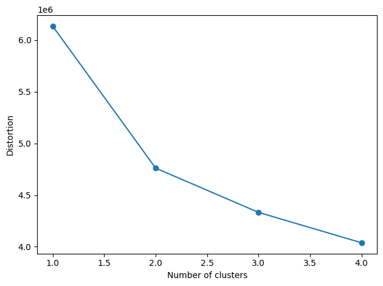

```python
#1. Forma de Elbow Method for K means funete: Sebastian Raschka
distortions = []
for i in range(1, 5):
    km = KMeans(n_clusters=i,
                init='k-means++',
                n_init=10,
                max_iter=300,
                random_state=0)
    km.fit(fraud_df_scaled_2)
    distortions.append(km.inertia_)
plt.plot(range(1, 5), distortions, marker='o')
plt.xlabel('Number of clusters')
plt.ylabel('Distortion')
plt.tight_layout()
#plt.savefig('images/11_03.png', dpi=300)
plt.show()
```

- Se observa la distorsion de 4.5 y en tres cluster es claro el codo, no hay varición

## Segundo forma Elbow Method

[output not shown]

[output cut: 76 more lines]

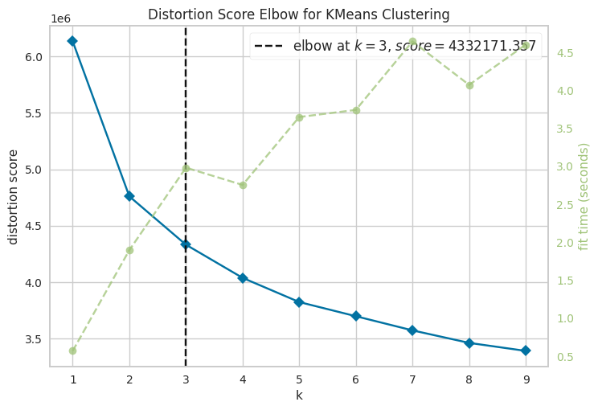

```python
# 2. Forma de Elbow Method for K means- Fuente: Indraneel Dutta Baruah
from sklearn.cluster import KMeans
# Import ElbowVisualizer
from yellowbrick.cluster import KElbowVisualizer
model = KMeans(random_state =10)
# k is range of number of clusters.
visualizer = KElbowVisualizer(model, k=(1,10), timings= True)
visualizer.fit(fraud_df_scaled_2)        # Fit the data to the visualizer
visualizer.show()        # Finalize and render the figure
```

## Silhouette Score Kmean

[output not shown]

[output cut: 64 more lines]

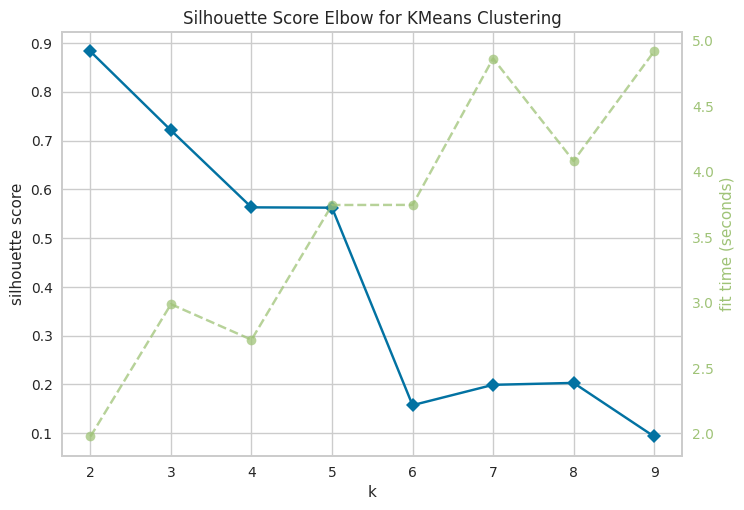

```
Optimal number of clusters based on silhouette score: [2]
```

```python
# 2. Forma ed Silhouette Score for K means. Fuente: Indraneel Dutta Baruah

# Import ElbowVisualizer
from yellowbrick.cluster import KElbowVisualizer
model = KMeans(random_state =10)
# k is range of number of clusters.
visualizer = KElbowVisualizer(model, k=(2,10),metric='silhouette', timings= True, locate_elbow=False)
visualizer.fit(fraud_df_scaled_2)        # Fit the data to the visualizer
visualizer.show()        # Finalize and render the figure

df3 = pd.DataFrame(visualizer.k_values_,columns=['centers'])
df3['scores'] = visualizer.k_scores_
df4 = df3[df3.scores == df3.scores.max()]
print('Optimal number of clusters based on silhouette score:', df4['centers'].tolist())
```

## Estadística de brecha para Kmeans

[output not shown]

[output cut: 40 more lines]

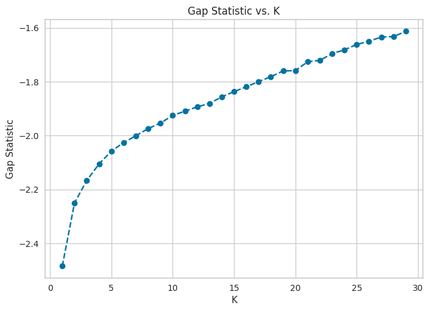

```python
# Gap Statistic for K means. Fuente: Indraneel Dutta Baruah
# Tecnica demoradita ###


def optimalK(data, nrefs=3, maxClusters=10):
    """
    Calculates KMeans optimal K using Gap Statistic from Tibshirani, Walther, Hastie
    Params:
        data: ndarry of shape (n_samples, n_features)
        nrefs: number of sample reference datasets to create
        maxClusters: Maximum number of clusters to test for
    Returns: (gaps, optimalK)
    """
    gaps = np.zeros((len(range(1, maxClusters)),))
    resultsdf = pd.DataFrame({'clusterCount':[], 'gap':[]})
    for gap_index, k in enumerate(range(1, maxClusters)):

        # Holder for reference dispersion results
        refDisps = np.zeros(nrefs)

        # For n references, generate random sample and perform kmeans getting resulting dispersion of each loop
        for i in range(nrefs):

            # Create new random reference set
            randomReference = np.random.random_sample(size=data.shape)

            # Fit to it
            km = KMeans(k, random_state =10)
            km.fit(randomReference)

            refDisp = km.inertia_
            refDisps[i] = refDisp

        # Fit cluster to original data and create dispersion
        km = KMeans(k)
        km.fit(data)

        origDisp = km.inertia_

        # Calculate gap statistic
        gap = np.log(np.mean(refDisps)) - np.log(origDisp)

        # Assign this loop's gap statistic to gaps
        gaps[gap_index] = gap

        resultsdf = resultsdf._append({'clusterCount':k, 'gap':gap}, ignore_index=True)

    return (gaps.argmax() + 1, resultsdf)

score_g, df = optimalK(fraud_df_scaled_2, nrefs=5, maxClusters=30)

plt.plot(df['clusterCount'], df['gap'], linestyle='--', marker='o', color='b');
plt.xlabel('K');
plt.ylabel('Gap Statistic');
plt.title('Gap Statistic vs. K');

df2 = df[df.gap == df.gap.max()]
```

## Calinski Harabasz Score para KMEANS

[output not shown]

[output cut: 55 more lines]

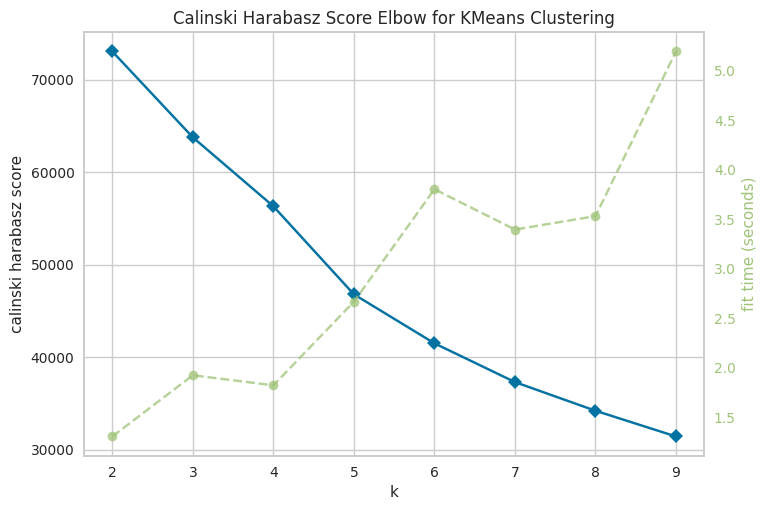

```
Optimal number of clusters based on calinski harabasz: [2]
```

```python
# Calinski Harabasz Score for K means. Fuente: Indraneel Dutta Baruah

# Import ElbowVisualizer
from yellowbrick.cluster import KElbowVisualizer
model = KMeans(random_state =10)
# k is range of number of clusters.
visualizer = KElbowVisualizer(model, k=(2,10),metric='calinski_harabasz', timings= True, locate_elbow=False)
visualizer.fit(fraud_df_scaled)        # Fit the data to the visualizer
visualizer.show()        # Finalize and render the figure


df3 = pd.DataFrame(visualizer.k_values_,columns=['centers'])
df3['scores'] = visualizer.k_scores_
df4 = df3[df3.scores == df3.scores.max()]
print('Optimal number of clusters based on calinski harabasz:', df4['centers'].tolist())
```

## Davies Bouldin Score para KMEANS

[output not shown]

[output cut: 17 more lines]

```
Optimal number of clusters based on DB score: [2]
```

[output not shown]

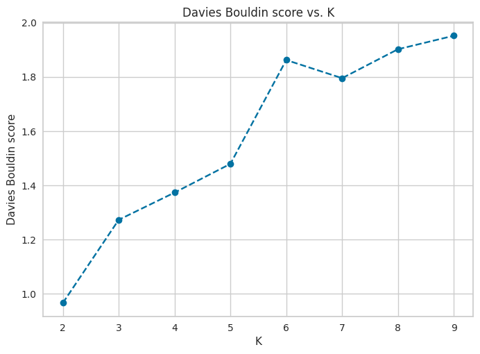

```python
# Davies Bouldin score for K means. Fuente: Indraneel Dutta Baruah

from sklearn.metrics import davies_bouldin_score

def get_kmeans_score(data, center):
    '''
    returns the kmeans score regarding Davies Bouldin for points to centers
    INPUT:
        data - the dataset you want to fit kmeans to
        center - the number of centers you want (the k value)
    OUTPUT:
        score - the Davies Bouldin score for the kmeans model fit to the data
    '''
    #instantiate kmeans
    kmeans = KMeans(n_clusters=center,random_state =10)

    # Then fit the model to your data using the fit method
    model = kmeans.fit_predict(fraud_df_scaled_2)

    # Calculate Silhoutte Score

    score = davies_bouldin_score(fraud_df_scaled_2, model)

    return score

scores = []
centers = list(range(2,10))

for center in centers:
    scores.append(get_kmeans_score(fraud_df_scaled_2, center))

plt.plot(centers, scores, linestyle='--', marker='o', color='b');
plt.xlabel('K');
plt.ylabel('Davies Bouldin score');
plt.title('Davies Bouldin score vs. K');


df3 = pd.DataFrame(centers,columns=['centers'])
df3['scores'] = scores
df4 = df3[df3.scores == df3.scores.min()]
print('Optimal number of clusters based on DB score:', df4['centers'].tolist())
```

# Para Etiquetar la data-Se necesita saber el # de Cluster y Usamos Kmeans

- Podria existir otra forma de hacerlo que seria aplica directaente PCA antes de hallar el No de clusters

```python
from sklearn.cluster import KMeans
# Realiza el clustering con K-Means
kmeans = KMeans(n_clusters=2)  # Número de clusters obtenidos tecnicas de clusters
labels = kmeans.fit_predict(fraud_df_scaled_2)
```

```python
# Agregación de las etiquetas numéricas al DataFrame
data1['cluster_label'] = labels
```

## Selección y Reducción de caracteristicas mediante Random Forests

```python
from sklearn.ensemble import RandomForestClassifier

X_fraud = fraud_df_scaled_2  # Tus características
y_fraud = data1['cluster_label']  # La etiqueta numérica que hemos asignado

clf_rnd = RandomForestClassifier(n_estimators=50, random_state=42, n_jobs=-1)
clf_rnd.fit(fraud_df_scaled_2, y_fraud)
```

```
RandomForestClassifier(n_estimators=50, n_jobs=-1, random_state=42)
```

```python
# Seleccionamos las características más importantes
feature_importances = {name: score for name, score in zip(list(X_fraud), clf_rnd.feature_importances_)}
feature_importances_sorted = pd.Series(feature_importances).sort_values(ascending=False)
```

```python
feature_importances_sorted
```

```
at             0.181879
act            0.118248
lct            0.091379
lt             0.090102
sale           0.084737
ap             0.066917
dp             0.061739
rect           0.043798
ceq            0.039063
ppegt          0.036276
ni             0.022752
dlc            0.020530
ib             0.018667
cogs           0.018361
txt            0.010135
re             0.008329
xint           0.008050
che            0.007763
txp            0.006837
dltt           0.006645
invt           0.005760
dltis          0.005556
ivst           0.005266
csho           0.005061
EBIT           0.004893
reoa           0.004604
ivao           0.004043
soft_assets    0.003053
sstk           0.002314
ch_fcf         0.001786
dch_rec        0.001759
ch_cs          0.001759
dpi            0.001628
ch_roa         0.001625
dch_inv        0.001591
ch_cm          0.001591
dch_wc         0.001424
bm             0.001413
prcc_f         0.001146
ch_rsst        0.001098
pstk           0.000357
issue          0.000066
dtype: float64
```

```python
feature_importances_sorted.sum()
```

```
1.0000000000000002
```

[output not shown]

[output cut: 176 more lines]

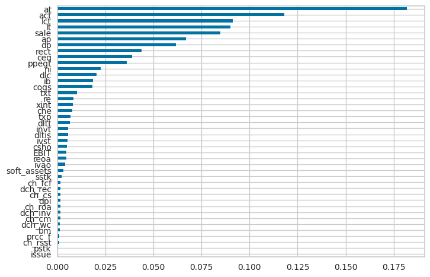

```python
from matplotlib import pyplot as plt
for_plot = pd.DataFrame({'x_axis':X_fraud.columns, 'y_axis':feature_importances_sorted}).sort_values(by='y_axis',ascending=True)
for_plot['y_axis'].plot.barh()
```

## Reducción del número de características

```python
'''Reducimos el conjunto de datos a las 8 características las más importantes mirando la imagen anterior
pero vemos adelante que a mayor # de caract. más componenestes y mayor explicabilidad '''
X_reduced = X_fraud[list(feature_importances_sorted.head(8).index)].copy()
X_reduced
```

|  | at | act | lct | lt | sale | ap | dp | rect |
| --- | --- | --- | --- | --- | --- | --- | --- | --- |
| 0 | -0.198503 | -0.196953 | -0.179284 | -0.198688 | -0.184039 | -0.173663 | -0.170357 | -0.170076 |
| 1 | -0.147705 | -0.097479 | -0.117085 | -0.150587 | -0.121418 | -0.021901 | -0.150293 | -0.091962 |
| 2 | -0.042476 | -0.148966 | -0.130820 | -0.082687 | -0.126016 | -0.135640 | 0.213831 | -0.130606 |
| 3 | -0.191926 | -0.183896 | -0.176929 | -0.197406 | -0.181382 | -0.169869 | -0.168722 | -0.165264 |
| 4 | -0.187897 | -0.163570 | -0.176494 | -0.197469 | -0.166286 | -0.173442 | -0.169790 | -0.165328 |
| ... | ... | ... | ... | ... | ... | ... | ... | ... |
| 146040 | -0.197988 | -0.195693 | -0.179010 | -0.198503 | -0.184102 | -0.173328 | -0.169719 | -0.170235 |
| 146041 | -0.191323 | -0.183958 | -0.173290 | -0.188063 | -0.177962 | -0.165952 | -0.154056 | -0.168018 |
| 146042 | -0.125712 | -0.148318 | -0.135940 | -0.158183 | -0.149399 | -0.090028 | -0.113490 | -0.123076 |
| 146043 | -0.198251 | -0.196196 | -0.179068 | -0.198594 | -0.184102 | -0.173567 | -0.170355 | -0.170267 |
| 146044 | -0.196891 | -0.193861 | -0.178151 | -0.197455 | -0.183062 | -0.172247 | -0.166929 | -0.169597 |

146045 rows × 8 columns

[output not shown]

[output cut: 169 more lines]

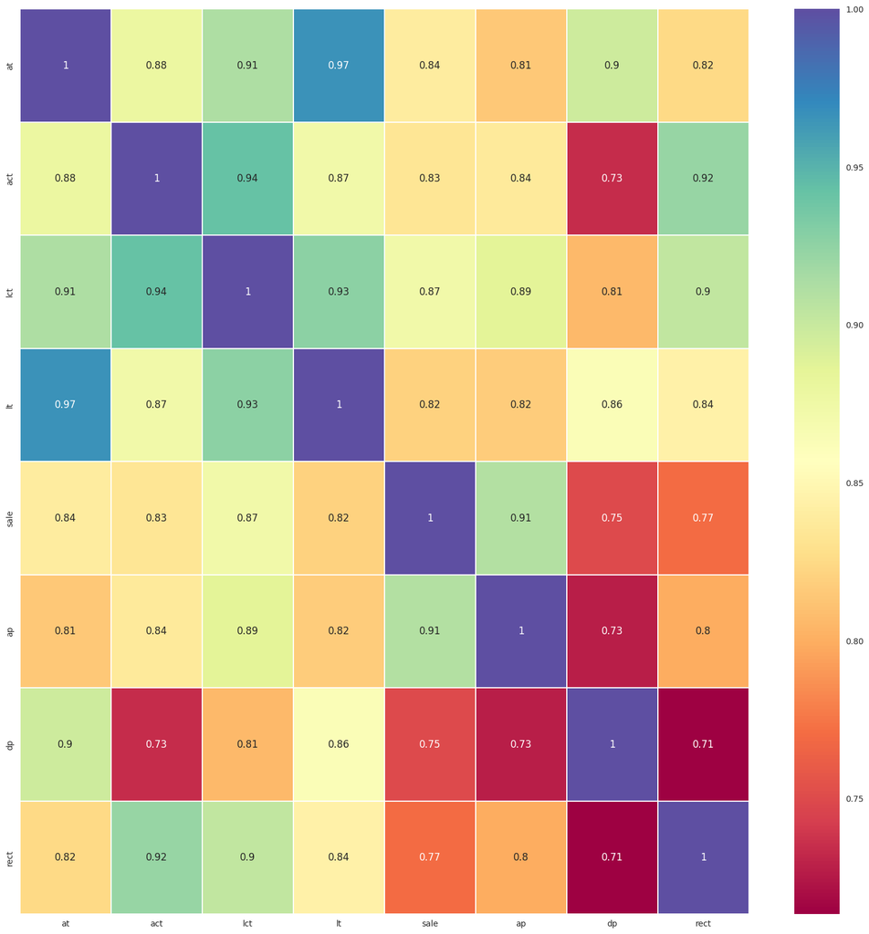

```python
# Volvemos a mirar la correlación de variables mediante heatmap
sns.heatmap(X_reduced.corr(),annot=True, cmap='Spectral', linewidths=0.1)
fig=plt.gcf()
fig.set_size_inches(20,20)
plt.show()
```

```python
#Esta desbalacedo necesita balanceo
y_fraud.value_counts()
```

```
cluster_label
0    145088
1       957
Name: count, dtype: int64
```

```python
X_reduced.info()
```

```
<class 'pandas.core.frame.DataFrame'>
RangeIndex: 146045 entries, 0 to 146044
Data columns (total 8 columns):
 #   Column  Non-Null Count   Dtype
---  ------  --------------   -----
 0   at      146045 non-null  float64
 1   act     146045 non-null  float64
 2   lct     146045 non-null  float64
 3   lt      146045 non-null  float64
 4   sale    146045 non-null  float64
 5   ap      146045 non-null  float64
 6   dp      146045 non-null  float64
 7   rect    146045 non-null  float64
dtypes: float64(8)
memory usage: 8.9 MB
```

```python
# In[4]:
print('#### Mezclar la base de datos###############')
#Mezclar la base de datos
X_reduced = X_reduced.sample(frac=1).reset_index(drop=True)
X_reduced.head(10)
```

```
#### Mezclar la base de datos###############
```

|  | at | act | lct | lt | sale | ap | dp | rect |
| --- | --- | --- | --- | --- | --- | --- | --- | --- |
| 0 | -0.196871 | -0.197044 | -0.176930 | -0.197659 | -0.184052 | -0.173655 | -0.170336 | -0.170267 |
| 1 | -0.151454 | -0.171549 | -0.143506 | -0.149200 | -0.145219 | -0.147769 | -0.139107 | -0.152570 |
| 2 | -0.186007 | -0.185507 | -0.175509 | -0.195015 | -0.177244 | -0.164905 | -0.151231 | -0.162388 |
| 3 | 1.888974 | -0.098989 | 0.256320 | 2.305347 | 0.199782 | 0.104057 | 4.356559 | 0.016804 |
| 4 | -0.197404 | -0.194702 | -0.178004 | -0.198118 | -0.183695 | -0.173411 | -0.170112 | -0.169446 |
| 5 | -0.196915 | -0.192573 | -0.178013 | -0.198106 | -0.182728 | -0.172699 | -0.169418 | -0.168366 |
| 6 | -0.190777 | -0.179103 | -0.171900 | -0.194974 | -0.176159 | -0.172904 | -0.158507 | -0.157143 |
| 7 | -0.177391 | -0.156968 | -0.167071 | -0.178571 | -0.155817 | -0.160749 | -0.148121 | -0.146254 |
| 8 | -0.107345 | -0.086711 | -0.121276 | -0.157898 | 0.078228 | -0.053206 | -0.103955 | -0.136140 |
| 9 | -0.023311 | -0.116770 | -0.129998 | -0.023604 | -0.124512 | -0.121217 | -0.051548 | -0.093165 |

# PCA

```python
# Función de bucle para identificar el número de componentes principales que explican al menos el 85% de la varianza

from sklearn.decomposition import PCA

for comp in range(2, X_reduced.shape[1]):
    modelo_pca = PCA(n_components= comp)
    modelo_pca.fit(X_reduced)
    comp_check = modelo_pca.explained_variance_ratio_
    final_comp = comp
    if comp_check.sum() > 0.85:
        break

Final_PCA = PCA(n_components= final_comp)
Final_PCA.fit(X_reduced)
cluster_df=Final_PCA.transform(X_reduced)

num_comps = comp_check.shape[0]
print("Using {} components, we can explain {}% of the variability in the original data.".format(final_comp,comp_check.sum()))
#con 3 comp explicacion de la variabilidad del 87% con mormalizado
```

```
Using 2 components, we can explain 0.9172385838592949% of the variability in the original data.
```

```python
#Se convierte el array a dataframe para añadir nombrs a los ejes(x=Componentes, Y=caracteriticas)
pd.DataFrame(modelo_pca.components_,columns=X_reduced.columns,index = [f'PC-{i+1}' for i in range(final_comp)]).T
```

|  | PC-1 | PC-2 |
| --- | --- | --- |
| at | 0.364204 | 0.332225 |
| act | 0.358839 | -0.280806 |
| lct | 0.370331 | -0.123233 |
| lt | 0.363238 | 0.261727 |
| sale | 0.346678 | -0.221474 |
| ap | 0.346601 | -0.333062 |
| dp | 0.330764 | 0.688868 |
| rect | 0.346093 | -0.304248 |

```python
#Vector con el porcentaje de influencia de la varianza explicada por cada componente,
# de las 12 variables resultantes del conjunto de datos
explained_variance = modelo_pca.explained_variance_ratio_
explained_variance
```

```
array([0.86610352, 0.05113507])
```

```python
explained_variance.sum()
```

```
0.9172385838592949
```

### Los componentes corresponden a combinaciones de las características originales, los propios componentes se almacenan como un atributo del objeto PCA ajustado:

```python
Final_PCA.components_
```

```
array([[ 0.36420388,  0.35883935,  0.37033143,  0.3632376 ,  0.34667764,
         0.3466013 ,  0.33076372,  0.34609311],
       [ 0.33222484, -0.28080599, -0.12323348,  0.26172685, -0.22147416,
        -0.33306188,  0.68886836, -0.30424755]])
```

- En esta matriz numpy, cada fila representa un componente principal, y cada columna se relaciona con las características originales. podemos visualizar esta relación con un mapa de calor:

### INFLUENCIA DE LAS VARIABLES POR COMPONENTES

```python
df_comp = pd.DataFrame(modelo_pca.components_, columns=X_reduced.columns,index = [f'PC-{i+1}' for i in range(final_comp)])
```

[output not shown]

[output cut: 92 more lines]

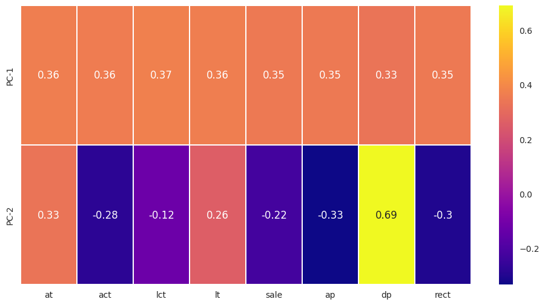

```python
sns.heatmap(df_comp,annot=True, cmap='plasma', linewidths=0.1);
fig=plt.gcf()
fig.set_size_inches(12,6)
plt.show()
```

Una vez calculadas las componentes principales, se puede conocer la varianza explicada por cada una de ellas, la proporción respecto al total y la proporción de varianza acumulada. Esta información está almacenada en los atributos **explained_variance_ y explained_variance_ratio_** del modelo.

[output not shown]

[output cut: 18 more lines]

```
----------------------------------------------------
Percentage of variance explanation by each component
----------------------------------------------------
[0.86610352 0.05113507]
```

[output not shown]

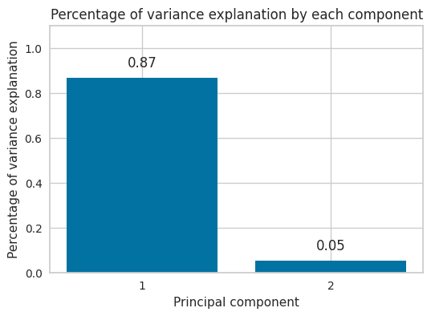

```python
# Porcentaje de varianza explicada por cada componente
# ==============================================================================
print('----------------------------------------------------')
print('Percentage of variance explanation by each component')
print('----------------------------------------------------')
print(modelo_pca.explained_variance_ratio_)

fig, ax = plt.subplots(nrows=1, ncols=1, figsize=(6, 4))
ax.bar(
    x      = np.arange(modelo_pca.n_components_) + 1,
    height = modelo_pca.explained_variance_ratio_
)

for x, y in zip(np.arange(len(X_reduced.columns)) + 1, modelo_pca.explained_variance_ratio_):
    label = round(y, 2)
    ax.annotate(
        label,
        (x,y),
        textcoords="offset points",
        xytext=(0,10),
        ha='center'
    )

ax.set_xticks(np.arange(modelo_pca.n_components_) + 1)
ax.set_ylim(0, 1.1)
ax.set_title('Percentage of variance explanation by each component')
ax.set_xlabel('Principal component')
ax.set_ylabel('Percentage of variance explanation');
```

```python
#Visualizacion
cluster_df.shape
cluster_df = pd.DataFrame(cluster_df,index=X_reduced.index)
cluster_df
```

|  | 0 | 1 |
| --- | --- | --- |
| 0 | -0.518993 | -0.006938 |
| 1 | -0.424435 | 0.008462 |
| 2 | -0.494971 | 0.000290 |
| 3 | 3.136896 | 4.144224 |
| 4 | -0.518345 | -0.008016 |
| ... | ... | ... |
| 146040 | -0.517842 | -0.007467 |
| 146041 | -0.486705 | 0.003829 |
| 146042 | -0.439599 | 0.008074 |
| 146043 | -0.520002 | -0.007744 |
| 146044 | -0.504231 | -0.003694 |

146045 rows × 2 columns

### Entrenamiento de KMEANS con el conjunto de datos reducido

```python
from sklearn.cluster import KMeans

kmeans_2 = KMeans(n_clusters=2, random_state=42)
clusters = kmeans_2.fit_predict(cluster_df)
```

```python
y_fraud.value_counts()
```

```
cluster_label
0    145088
1       957
Name: count, dtype: int64
```

```python
# Evaluamos los clusters y el contenido que se han formado
from collections import Counter
counter = Counter(clusters.tolist())
bad_counter = Counter(clusters[y_fraud == 1].tolist())

for key in sorted(counter.keys()):
    print("Label {0} has {1} samples - {2} are malicious samples".format(
        key, counter[key], bad_counter[key]))
```

```
Label 0 has 145101 samples - 951 are malicious samples
Label 1 has 944 samples - 6 are malicious samples
```

## Evaluación de los resultados- KMEANS

#### Metricas Externas(en función de etiquetas conocidas, data no usada en clustering y clusters del objeto Kmeans

```python
def purity_score(y_true, y_pred):
    # compute contingency matrix (also called confusion matrix)
    contingency_matrix = metrics.cluster.contingency_matrix(y_true, y_pred)
    # return purity
    return np.sum(np.amax(contingency_matrix, axis=0)) / np.sum(contingency_matrix)
```

```python
# Calculamos el purity score, es importante darse cuenta de que recibe las etiquetas
print("Purity Score: %0.2f" % purity_score(y_fraud,  kmeans_2.labels_))

print("Homogeneity_score: %0.2f" % metrics.homogeneity_score(y_fraud,  kmeans_2.labels_))

print("v_measure_score:  %0.2f" % metrics.v_measure_score(y_fraud, clusters))

print("Adjusted_rand_score: %0.2f" % metrics.adjusted_rand_score(y_fraud, clusters))

print("Adjusted_mutual_info_score: %0.2f" % metrics.adjusted_mutual_info_score(y_fraud, clusters))
```

```
Purity Score: 0.99
Homogeneity_score: 0.00
v_measure_score:  0.00
Adjusted_rand_score: -0.00
Adjusted_mutual_info_score: -0.00
```

#### Metricas Internas(Función de los datos agrupados y clusters del objeto Kmeans)

```python
# Calculamos el coeficiente de Shiloutte, es importante darse cuenta de que no le pasamos las etiquetas
print("Shiloutte: %0.2f" % metrics.silhouette_score(cluster_df, kmeans_2.labels_, metric='euclidean'))

# Calculamos el Calinski harabasz score, es importante darse cuenta de que no le pasamos las etiquetas, se escogio data escalada
print("Calinski harabasz: %0.2f" % metrics.calinski_harabasz_score(cluster_df, clusters))

from sklearn.metrics import davies_bouldin_score
print("davies_bouldin_score:  %0.3f" % davies_bouldin_score(cluster_df, clusters))
```

```
Shiloutte: 0.97
Calinski harabasz: 211944.97
davies_bouldin_score:  0.509
```

#### Segunda opción

```python
# K means
from sklearn.cluster import KMeans
from sklearn.metrics import silhouette_score
from sklearn.metrics import calinski_harabasz_score
from sklearn.metrics import davies_bouldin_score
# Fit K-Means
kmeans_1 = KMeans(n_clusters=2, random_state= 10)
# Use fit_predict to cluster the dataset
predictions = kmeans_1.fit_predict(X_reduced)
# Calculate cluster validation metrics
score_kemans_s = silhouette_score(X_reduced, kmeans_2.labels_, metric='euclidean')
score_kemans_c = calinski_harabasz_score(X_reduced, kmeans_2.labels_)
score_kemans_d = davies_bouldin_score(X_reduced, predictions)


print('Silhouette Score: %.4f' % score_kemans_s)
print('Calinski Harabasz Score: %.4f' % score_kemans_c)
print('Davies Bouldin Score: %.4f' % score_kemans_d)
```

```
Silhouette Score: 0.9684
Calinski Harabasz Score: 173626.2904
Davies Bouldin Score: 0.5981
```

# GAP Kmeans

```python
def gap_stat_kmeans(data = X_reduced,nrefs=3,k=2):
    # Gap Stat
    refDisps = np.zeros(nrefs)
    # For n references, generate random sample and perform kmeans getting resulting dispersion of each loop
    for i in range(nrefs):

        # Create new random reference set
        randomReference = np.random.random_sample(size=X_reduced.shape)

        # Fit to it
        km = KMeans(k, random_state =10)
        km.fit(randomReference)

        refDisp = km.inertia_
        refDisps[i] = refDisp

    # Fit cluster to original data and create dispersion
    km = KMeans(k)
    km.fit(X_reduced)

    origDisp = km.inertia_

    # Calculate gap statistic
    score_g = np.log(np.mean(refDisps)) - np.log(origDisp)
    return score_g

score_kemans_g = gap_stat_kmeans(X_reduced,3,4)
print('Gap Statistic Score: %.4f' % score_kemans_g)
```

```
Gap Statistic Score: -1.2424
```

## Mapa de distancia entre grupos KMEANS

[output not shown]

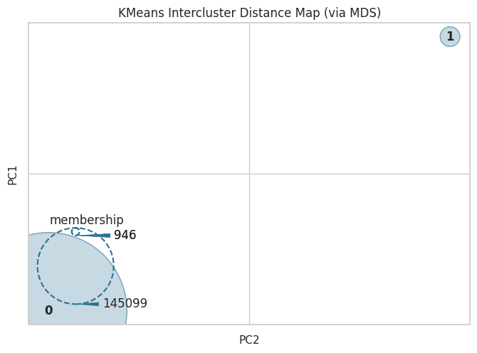

```python
# Inter cluster distance map

from yellowbrick.cluster import InterclusterDistance

# Instantiate the clustering model and visualizer

visualizer = InterclusterDistance(kmeans_1)

visualizer.fit(X_reduced)        # Fit the data to the visualizer
visualizer.show()        # Finalize and render the figure
```

# GMM Clustering

```python
# BIC for GMM

from sklearn.mixture import GaussianMixture
n_components = range(1, 30)
covariance_type = ['spherical', 'tied', 'diag', 'full']
score=[]
for cov in covariance_type:
    for n_comp in n_components:
        gmm=GaussianMixture(n_components=n_comp,covariance_type=cov, random_state = 10)
        gmm.fit(fraud_df_scaled_2)
        score.append((cov,n_comp,gmm.bic(fraud_df_scaled_2)))
score_1 = pd.DataFrame(score)
score_1.columns = ['Covariance_Type', 'N_Components','BIC_Score']
score_2 = score_1[score_1.BIC_Score == score_1.BIC_Score.min()]

score_2.head(n=2)
```

[output not shown]

## Silhouette Score for GMM

```python
from sklearn.cluster import KMeans
from sklearn.metrics import silhouette_score
# Silhouette Score for GMM
n_components = range(2, 30)
covariance_type = ['spherical', 'tied', 'diag', 'full']
score=[]
for cov in covariance_type:
    for n_comp in n_components:
        gmm=GaussianMixture(n_components=n_comp,covariance_type=cov,random_state = 10)
        model = gmm.fit(fraud_df_scaled_2)
        model_2 = model.predict(fraud_df_scaled_2)
        score_s = silhouette_score(fraud_df_scaled_2, model_2, metric='euclidean')
        score.append((cov,n_comp,score_s))
score_1 = pd.DataFrame(score)
score_1.columns = ['Covariance_Type', 'N_Components','Silhouette_Score']
score_2 = score_1[score_1.Silhouette_Score == score_1.Silhouette_Score.max()]
score_2.head(n=2)
```

[output not shown]

## Calinski Harabasz Score for GMM

```python
# Calinski Harabasz Score for GMM

n_components = range(2, 30)
covariance_type = ['spherical', 'tied', 'diag', 'full']
score=[]
for cov in covariance_type:
    for n_comp in n_components:
        gmm=GaussianMixture(n_components=n_comp,covariance_type=cov, random_state = 10)
        model = gmm.fit(fraud_df_scaled_2)
        model_2 = model.predict(fraud_df_scaled_2)
        score_c = calinski_harabasz_score(fraud_df_scaled_2, model_2)
        score.append((cov,n_comp,score_c))
score_1 = pd.DataFrame(score)
score_1.columns = ['Covariance_Type', 'N_Components','Calinski_Harabasz_Score']
score_2 = score_1[score_1.Calinski_Harabasz_Score == score_1.Calinski_Harabasz_Score.max()]
score_2.head(n=5)
```

[output not shown]

## Davies Bouldin Score for GMM

```python
# Davies Bouldin Score for GMM
n_components = range(2, 30)
covariance_type = ['spherical', 'tied', 'diag', 'full']
score=[]
for cov in covariance_type:
    for n_comp in n_components:
        gmm=GaussianMixture(n_components=n_comp,covariance_type=cov, random_state = 10)
        model = gmm.fit(fraud_df_scaled_2)
        model_2 = model.predict(fraud_df_scaled_2)
        score_d = davies_bouldin_score(fraud_df_scaled_2, model_2)
        score.append((cov,n_comp,score_d))
score_1 = pd.DataFrame(score)
score_1.columns = ['Covariance_Type', 'N_Components','Davies_Bouldin_Score']
score_2 = score_1[score_1.Davies_Bouldin_Score == score_1.Davies_Bouldin_Score.max()]
score_2.head(n=2)
```

[output not shown]

```python
# gaussian mixture clustering
from numpy import unique
from numpy import where
from sklearn.datasets import make_classification
from sklearn.mixture import GaussianMixture
from matplotlib import pyplot
# define the model
model1 = GaussianMixture(n_components= 27,covariance_type= "full", random_state = 10)
# fit the model
model1.fit(fraud_df_scaled_2)
# assign a cluster to each example
yhat = model1.predict(fraud_df_scaled_2)
# retrieve unique clusters
clusters = unique(yhat)


# Calculate cluster validation score

score_gmm_s = silhouette_score(fraud_df_scaled_2, yhat, metric='euclidean')

score_gmm_c = calinski_harabasz_score(fraud_df_scaled_2, yhat)

score_gmm_d = davies_bouldin_score(fraud_df_scaled_2, yhat)


print('Silhouette Score: %.4f' % score_gmm_s)
print('Calinski Harabasz Score: %.4f' % score_gmm_c)
print('Davies Bouldin Score: %.4f' % score_gmm_d)
```

[output not shown]

# PCA CON OTROS MODELOS

```python
from sklearn.decomposition import PCA

for comp in range(2, fraud_df_scaled_2.shape[1]):
    modelo_pca = PCA(n_components= comp)
    modelo_pca.fit(fraud_df_scaled_2)
    comp_check = modelo_pca.explained_variance_ratio_
    final_comp = comp
    if comp_check.sum() > 0.85:
        break

Final_PCA = PCA(n_components= final_comp)
Final_PCA.fit(X_reduced)
cluster_df=Final_PCA.transform(fraud_df_scaled_2)

num_comps = comp_check.shape[0]
print("Using {} components, we can explain {}% of the variability in the original data.".format(final_comp,comp_check.sum()))
#con 3 comp explicacion de la variabilidad del 87% con mormalizado
```

[output not shown]

# DBSCAN

```python
# parameter tuning for eps
from sklearn.neighbors import NearestNeighbors
nearest_neighbors = NearestNeighbors(n_neighbors=11)
neighbors = nearest_neighbors.fit(cluster_df)
distances, indices = neighbors.kneighbors(cluster_df)
distances = np.sort(distances[:,10], axis=0)

from kneed import KneeLocator
i = np.arange(len(distances))
knee = KneeLocator(i, distances, S=1, curve='convex', direction='increasing', interp_method='polynomial')
fig = plt.figure(figsize=(5, 5))
knee.plot_knee()
plt.xlabel("Points")
plt.ylabel("Distance")

print(distances[knee.knee])
```

[output not shown]

## Silhouette Score para DBSCAN

```python
# Silhouette Score for DBSCAN

from sklearn.metrics import silhouette_score
from sklearn.cluster import DBSCAN

def get_dbscan_score(data, center):
    '''

    INPUT:
        data - the dataset you want to fit kmeans to
        center - the number of centers you want (the k value)
    OUTPUT:
        score - the Silhouette Score for DBSCAN
    '''
    #instantiate kmeans
    dbscan = DBSCAN(eps= 2.855134125340192, min_samples=center)

    # Then fit the model to your data using the fit method
    model = dbscan.fit(cluster_df)

    # Calculate Silhoutte Score

    score = silhouette_score(cluster_df, model.labels_, metric='euclidean')

    return score

scores = []
centers = list(range(2,30))

for center in centers:
    scores.append(get_dbscan_score(cluster_df, center))

plt.plot(centers, scores, linestyle='--', marker='o', color='b');
plt.xlabel('min_samples');
plt.ylabel('Silhouette Score');
plt.title('Silhouette Score vs. min_samples');

df3 = pd.DataFrame(centers,columns=['min_samples'])
df3['scores'] = scores
df4 = df3[df3.scores == df3.scores.max()]
print('Optimal number of min_samples based on silhouette score:', df4['min_samples'].tolist())
```

[output not shown]

## Calinski Harabasz para DBSCAN

```python
# Calinski Harabasz for DBSCAN

from sklearn.metrics import calinski_harabasz_score

def get_dbscan_score(data, center):
    '''

    INPUT:
        data - the dataset you want to fit dbscan to
        center - the number of centers you want (the k value)
    OUTPUT:
        score - the Calinski Harabasz score for the dbscan model fit to the data
    '''
    #instantiate dbscan
    dbscan = DBSCAN(eps= 1.9335816413107338, min_samples=center)

    # Then fit the model to your data using the fit method
    model = dbscan.fit(cluster_df)

    # Calculate Silhoutte Score

    score = calinski_harabasz_score(cluster_df, dbscan.labels_)

    return score

scores = []
centers = list(range(2,30))

for center in centers:
    scores.append(get_dbscan_score(cluster_df, center))

plt.plot(centers, scores, linestyle='--', marker='o', color='b');
plt.xlabel('min_sample');
plt.ylabel('Calinski Harabasz');
plt.title('Calinski Harabasz vs. min_sample');

df3 = pd.DataFrame(centers,columns=['min_sample'])
df3['scores'] = scores
df4 = df3[df3.scores == df3.scores.max()]
print('Optimal number of min_sample based on Calinski Harabasz score:', df4['min_sample'].tolist())
```

[output not shown]

## Davies Bouldin score for DBSCAN

```python
# Davies Bouldin score for DBSCAN

from sklearn.metrics import davies_bouldin_score

def get_dbscan_score(data, center):
    '''
    returns the dbscan score regarding Davies Bouldin for points to centers
    INPUT:
        data - the dataset you want to fit dbscan to
        center - the number of centers you want (the k value)
    OUTPUT:
        score - the Davies Bouldin score for the dbscan model fit to the data
    '''
    #instantiate dbscan
    dbscan = DBSCAN(eps= 1.9335816413107338, min_samples=center)

    # Then fit the model to your data using the fit method
    model = dbscan.fit_predict(X_reduced)

    # Calculate Silhoutte Score

    score = davies_bouldin_score(X_reduced, model)

    return score

scores = []
centers = list(range(2,30))

for center in centers:
    scores.append(get_dbscan_score(X_reduced, center))

plt.plot(centers, scores, linestyle='--', marker='o', color='b');
plt.xlabel('min_samples');
plt.ylabel('Davies Bouldin score');
plt.title('Davies Bouldin score vs. min_samples');


df3 = pd.DataFrame(centers,columns=['min_samples'])
df3['scores'] = scores
df4 = df3[df3.scores == df3.scores.min()]
print('Optimal number of min_samples based on DB score:', df4['min_samples'].tolist())
```

[output not shown]

```python
# dbscan clustering
from numpy import unique
from numpy import where
from sklearn.datasets import make_classification
from sklearn.cluster import DBSCAN
from matplotlib import pyplot
# define dataset
# define the model
model = DBSCAN(eps=1.9335816413107338, min_samples= 18)

# rule of thumb for min_samples: 2*len(cluster_df.columns)

# fit model and predict clusters
yhat = model.fit_predict(X_reduced)
# retrieve unique clusters
clusters = unique(yhat)


# Calculate cluster validation metrics

score_dbsacn_s = silhouette_score(X_reduced, yhat, metric='euclidean')

score_dbsacn_c = calinski_harabasz_score(X_reduced, yhat)

score_dbsacn_d = davies_bouldin_score(X_reduced, yhat)

print('Silhouette Score: %.4f' % score_dbsacn_s)
print('Calinski Harabasz Score: %.4f' % score_dbsacn_c)
print('Davies Bouldin Score: %.4f' % score_dbsacn_d)
```

[output not shown]

## Entrenamiento de DBSCAN con el conjunto de datos reducido

```python
from sklearn.cluster import DBSCAN

model = DBSCAN(n_clusters=3, random_state=42)
clusters = model.fit_predict(cluster_df)
```

```python
# Agregación de las etiquetas numéricas al DataFrame
data1['cluster_label'] = labels
```

```python
X_fraud = X_reduced_1  # Tus características
y_fraud = data1['cluster_label']  # La etiqueta numérica que hemos asignado
```

```python
y_fraud.value_counts()
```

```python
from collections import Counter

# Evaluamos los clusters y el contenido que se han formado
counter = Counter(clusters.tolist())
bad_counter = Counter(clusters[y_fraud == 1].tolist())

for key in sorted(counter.keys()):
    print("Label {0} has {1} samples - {2} are malicious samples".format(
        key, counter[key], bad_counter[key]))
```

[output not shown]

### Evaluación de los resultados métricas DBSCAN

#### Metricas Externas(en función de etiquetas conocidas, data no usada en clustering y clusters del objto DBSCAN

```python
# Calculamos el purity score, es importante darse cuenta de que recibe las etiquetas
print("Purity Score: %0.2f" % purity_score(y_fraud,  model.labels_))
print("Homogeneity_score: %0.2f" % metrics.homogeneity_score(y_fraud,  model.labels_))
print("Completeness_score: %0.2f" % metrics.completeness_score(y_fraud, clusters))
print("v_measure_score:  %0.2f" % metrics.v_measure_score(y_fraud, clusters))
print("Adjusted_rand_score: %0.2f" % metrics.adjusted_rand_score(y_fraud, clusters))
print("Adjusted_mutual_info_score: %0.2f" % metrics.adjusted_mutual_info_score(y_fraud, clusters))
```

[output not shown]

#### Metricas Internas(Función de los datos agrupados y clusters del objeto DBSCAN)

```python
# Calculamos el coeficiente de Shiloutte, es importante darse cuenta de que no le pasamos las etiquetas
print("Shiloutte: %0.2f" % metrics.silhouette_score(cluster_df, model.labels_, metric='euclidean'))
# Calculamos el Calinski harabasz score, es importante darse cuenta de que no le pasamos las etiquetas, se escogio data escalada
print("Calinski harabasz: %0.2f" % metrics.calinski_harabasz_score(cluster_df, clusters))
from sklearn.metrics import davies_bouldin_score
print("davies_bouldin_score:  %0.3f" % davies_bouldin_score(cluster_df, clusters))
```

[output not shown]

# Hierachical clustering

```python
# Elbow Method for Heirarchical Clustering
from sklearn.cluster import MiniBatchKMeans
# Import ElbowVisualizer
from yellowbrick.cluster import KElbowVisualizer
from sklearn.cluster import AgglomerativeClustering

# define dataset
# define the model


model = AgglomerativeClustering()
# k is range of number of clusters.
visualizer = KElbowVisualizer(model, k=(2,30), timings= True)
visualizer.fit(cluster_df)        # Fit the data to the visualizer
visualizer.show()        # Finalize and render the figure
```

[output not shown]

```python
# Silhouette Score for Hierarchical Clustering

# Import ElbowVisualizer
from yellowbrick.cluster import KElbowVisualizer
model = AgglomerativeClustering()
# k is range of number of clusters.
visualizer = KElbowVisualizer(model, k=(2,30),metric='silhouette', timings= True, locate_elbow=False)
visualizer.fit(cluster_df)        # Fit the data to the visualizer
visualizer.show()        # Finalize and render the figure

df3 = pd.DataFrame(visualizer.k_values_,columns=['centers'])
df3['scores'] = visualizer.k_scores_
df4 = df3[df3.scores == df3.scores.max()]
print('Optimal number of clusters based on silhouette score:', df4['centers'].tolist())
```

[output not shown]

```python
# Calinski Harabasz Score for Hierarchical Clustering

# Import ElbowVisualizer
from yellowbrick.cluster import KElbowVisualizer
model = AgglomerativeClustering()
# k is range of number of clusters.
visualizer = KElbowVisualizer(model, k=(2,30),metric='calinski_harabasz', timings= True, locate_elbow=False)
visualizer.fit(cluster_df)        # Fit the data to the visualizer
visualizer.show()        # Finalize and render the figure


df3 = pd.DataFrame(visualizer.k_values_,columns=['centers'])
df3['scores'] = visualizer.k_scores_
df4 = df3[df3.scores == df3.scores.max()]
print('Optimal number of clusters based on silhouette score:', df4['centers'].tolist())
```

[output not shown]

```python
# Davies Bouldin score for Hierarchical Clustering

from sklearn.metrics import davies_bouldin_score

def get_AG_clustering_score(data, center):
    '''
    returns the AG_clustering score regarding Davies Bouldin for points to centers
    INPUT:
        data - the dataset you want to fit AG_clustering to
        center - the number of centers you want (the k value)
    OUTPUT:
        score - the Davies Bouldin score for the AG_clustering model fit to the data
    '''
    #instantiate AG_clustering
    AG_clustering = AgglomerativeClustering(n_clusters= center)

    # Then fit the model to your data using the fit method
    model = AG_clustering.fit_predict(cluster_df)

    # Calculate Silhoutte Score

    score = davies_bouldin_score(cluster_df, model)

    return score

scores = []
centers = list(range(2,30))

for center in centers:
    scores.append(get_AG_clustering_score(cluster_df, center))

plt.plot(centers, scores, linestyle='--', marker='o', color='b');
plt.xlabel('K');
plt.ylabel('Davies Bouldin score');
plt.title('Davies Bouldin score vs. K');


df3 = pd.DataFrame(centers,columns=['centers'])
df3['scores'] = scores
df4 = df3[df3.scores == df3.scores.min()]
print('Optimal number of clusters based on DB score:', df4['centers'].tolist())
```

[output not shown]

```python
# Dendrogram for Hierarchical Clustering
import scipy.cluster.hierarchy as shc
from matplotlib import pyplot
pyplot.figure(figsize=(10, 7))
pyplot.title("Dendrograms")
dend = shc.dendrogram(shc.linkage(cluster_df, method='ward'))
```

[output not shown]

```python
# Agglomerative clustering
from numpy import unique
from numpy import where
from sklearn.cluster import AgglomerativeClustering
from matplotlib import pyplot

# define the model
model = AgglomerativeClustering(n_clusters=4)
# fit model and predict clusters
yhat = model.fit(cluster_df)
yhat_2 = model.fit_predict(cluster_df)
# retrieve unique clusters
clusters = unique(yhat)


# Calculate cluster validation metrics

score_AGclustering_s = silhouette_score(cluster_df, yhat.labels_, metric='euclidean')

score_AGclustering_c = calinski_harabasz_score(cluster_df, yhat.labels_)

score_AGclustering_d = davies_bouldin_score(cluster_df, yhat_2)



print('Silhouette Score: %.4f' % score_AGclustering_s)
print('Calinski Harabasz Score: %.4f' % score_AGclustering_c)

print('Davies Bouldin Score: %.4f' % score_AGclustering_d)
```

[output not shown]